# Dopamine depletion in Parkinson’s increases directed but not random exploration

Authors

Affiliations

Björn Meder

Health and Medical University, Potsdam, Germany

Martha Sterf

Medical School Berlin, Berlin, Germany

Charley M. Wu

University of Tübingen, Tübingen, Germany

Matthias Guggenmos

Health and Medical University, Potsdam, Germany

Published

April 15, 2026

```r
# Housekeeping: Load packages and helper functions
# Housekeeping
knitr::opts_chunk$set(echo = TRUE)
knitr::opts_chunk$set(message = FALSE)
knitr::opts_chunk$set(warning = FALSE)
knitr::opts_chunk$set(fig.align='center')
knitr::opts_chunk$set(prefer_html = TRUE)

options(knitr.kable.NA = '')
options(brms.backend = "cmdstanr") # more stability for M1 Mac

packages <- c("gridExtra", "BayesFactor", "tidyverse", "RColorBrewer", "lme4", "sjPlot", "lsr", "brms",  "kableExtra", "afex", "emmeans", "viridis", "ggpubr", "hms", "scales", "cowplot", "waffle",  "ggthemes", "parameters", "rstatix", "magick", "grid", "cetcolor", "ggcorrplot", "gtsummary",  "webshot", "webshot2", "bridgesampling", "cmdstanr", "modelsummary", "broom.mixed", "bayestestR", "report")
lapply(packages, require, character.only = TRUE)

set.seed(0815)

# file with various statistical functions, among other things it provides tests for Bayes Factors (BFs)
source('statisticalTests.R')

# Wrapper for brm models such that it saves the full model the first time it is run, otherwise it loads it from disk
run_model <- function(expr, modelName, path='brm', reuse = TRUE) {
  path <- paste0(path,'/', modelName, ".brm")
  if (reuse) {
    fit <- suppressWarnings(try(readRDS(path), silent = TRUE))
  }
  if (is(fit, "try-error")) {
    fit <- eval(expr)
    saveRDS(fit, file = path)
  }
  fit
}

# Setting some plotting params
w_box          <- 0.2      # width of boxplot, also used for jittering points and lines
line_jitter    <- w_box / 2
xAnnotate      <- -0.3

# jitter params
jit_height  <- 0.01
jit_width   <- 0.05
jit_alpha   <- 0.6

# colors
# groupcolors    <- c("#7570b3", "#1b9e77", "#d95f02")
groupcolors    <- c("#d95f02", "#1b9e77", "#7570b3")
choice3_colors <- c("#e7298a", "#66a61e", "#e6ab02")

grouplabels <- c("Control" = "Control", "PD+" = "PD+", "PD-" = "PD\u2212") # proper minus sign
```

# 1 Preamble

This document provides R code for the statistical analyses and plots of the behavioral data reported in the article

Meder, B., Sterf, M. Wu, C.M, & Guggenmos, M. (2025). Dopamine depletion in Parkinson’s increases directed but not random exploration. *PsyArXiv*

All analyses are fully reproducible, with the R code shown alongside the results, and random seeds set to ensure identical outputs across runs. Full session info is provided at the end of the document. All materials, including this document and all data, are available at:

https://github.com/charleywu/gridsearch_parkinsons

# 2 Data

All behavioral data are stored in the following files:

- `data_gridsearch_parkinson.csv` contains the behavioral data from rounds 1-9 from the task
- `data_gridsearch_subjects.csv` contains participant information, and
- `data_gridsearch_Parkinson_bonusround.csv` contains the behavioral data from round 10 from the task (“bonus round”).

Data frame `dat` includes all info from `data_gridsearch_parkinson.csv` and `data_gridsearch_subjects.csv`, with the following variables (Table 2):

- `id`: participant id
- `age` is participant age in years
- `gender`: (m)ale, (f)emale, (d)iverse
- `group`: condition, where PD+ = PArkinson patients *on* medication, PD- = Parkinson patients *off* medication, and Control = age-matched control patients with polyneurpathies
- `BDI`: Depression score according to the German verison of Beck’s Depression Inventory II
- `MMSE`: Score on Mini Mental Status Examination
- `LDD`: Daily Levodopa dose (only patients who consented to the access of their medical records; 14 PD$-$ and 12 PD$+$ patients)
- `LEDD`: Levodopa equivalent daily dose, calculated according to Jost et al. (2023)
- `hoehn-yahr`: PD severity according to the Hoehn-Yahr scale
- `last_ldopa`: time of the last levodopa dose (HH:MM)
- `next_ldopa`: scheduled time of the next levodopa dose (HH:MM)
- `time_exp`: time of the experiment (HH:MM)
- `time_since_ldopa`: time since last levodopa (in minutes)
- `x` and `y` are the sampled coordinates on the grid
- `chosen`: are the `x` and `y` coordinates of the chosen tile
- `z` is the reward obtained from the chosen tile, normalized to the range 0-1. Re-clicked tiles could show small variations in the observed color (i.e., underlying reward) due to normally distributed noise,$\epsilon∼N(0,1)$.
- `z_scaled` is the observed outcome (reward), scaled in each round to a randomly drawn maximum value in the range of 70% to 90% of the highest reward value
- `time`is the timestamp of clicks
- `trial` is the trial number (0-25), with 0 corresponding to the initially revealed random tile, i.e. trial 1 is the first choice
- `round` is the round number (1 through 10), with 1=practice round (not analyzed) and 10=bonus round (analyzed only for bonus round judgments)
- `distance` is the Manhattan distance between consecutive clicks. `NA` for trial 0, the initially revealed random tile
- `type_choice` categorizes consecutive clicks as “repeat” (clicking the same tile as in the previous round), “near” (clicking a directly neighboring tile, i.e. distance=1), and “far” (clicking a tile with distance > 1). `NA` for trial 0, i.e., the initially revealed random tile.
- `previous_reward` is the reward `z` obtained on the previous step. `NA` for trial 0, i.e., the initially revealed random tile.

```r
########################################################
# get behavioral data
########################################################
dat_gridsearch <- read_csv("data/data_gridsearch_Parkinson.csv", show_col_types = FALSE) %>%
  mutate(type_choice  = factor(type_choice, levels = c("Repeat", "Near", "Far")))

# normalize reward and previous reward
dat_gridsearch$z = dat_gridsearch$z / 50
dat_gridsearch$previous_reward = dat_gridsearch$previous_reward / 50
# length(unique(dat_gridsearch$id))

# compute latency between choices
dat_gridsearch <-  dat_gridsearch %>%
  arrange(id, round, trial) %>%
  group_by(id, round) %>%
  mutate(
    latency_ms = time - lag(time)
  ) %>%
  ungroup()

########################################################
# get bonus round data
########################################################
dat_bonus   <- read_csv(file="data/data_gridsearch_Parkinson_bonusround.csv") %>%
  mutate(bonus_environment = as.factor(bonus_environment))
# length(unique(df_bonus_round$id))

########################################################
# get subject data
########################################################
dat_sample <- read_delim("data/data_gridsearch_subjects.csv", escape_double = FALSE, trim_ws = TRUE, show_col_types = FALSE) %>%
  mutate(gender = as.factor(gender),
         # group  = factor(group, levels = c("Control", "PD+", "PD-"))) %>%
         #group  = factor(group, levels = c("Control", "PD+", "PD-"), labels = c("Control", "PD+", "PD-"))) %>%
         group = fct_recode(group,
                            "Control" = "PNP",
                            "PD+"  = "PD+",
                            "PD-" = "PD-"
         ),
         group = fct_relevel(group, "PD-", "PD+", "Control") #
  ) %>%
  mutate(last_ldopa = if_else(group != "Control", as_hms(last_ldopa), as_hms(NA)),
         next_ldopa = if_else(group != "Control", as_hms(next_ldopa), as_hms(NA)),
         time_exp = if_else(group != "Control", as_hms(time_exp), as_hms(NA))) %>%
  mutate(time_since_ldopa = as.numeric(time_exp - last_ldopa, unit = "mins"))

# one participants' data was lost due to a computer crash
# dat_sample$id[!dat_sample$id %in% dat_gridsearch$id]

dat_sample <- dat_sample[dat_sample$id %in% dat_gridsearch$id, ]
#length(unique(dat_sample$id))


# get medication info (note: not available for all PD patients)
dat_medication <- read_csv(file="data/levodopa.csv", col_select = -1)

dat_sample <- dat_sample %>%
  left_join(dat_medication, by = "id")

# combine behavioral and subject data
dat <- dat_sample %>%
  inner_join(dat_gridsearch, by = "id") %>%
  arrange(group)

# length(unique(dat$id))



########################################################
# get modeling data
########################################################
modelFits <- read.csv('modelResults/modelFit.csv') # generated by dataProcessing_gridSearchParkinson.R
# length(unique(modelFits$id))
```

# 3 Abstract

# 4 Behavioral experiment

We investigated how patients with Parkinson’s disease (PD) manage the explore-exploit trade-off using a spatially correlated multi-armed bandit task. Participants accumulated rewards by selecting tiles (options) with normally distributed rewards. The spatial correlation between rewards facilitated generalization, allowing participants to adapt to the structure of the environment and balance exploring new options versus exploiting known high-reward options.

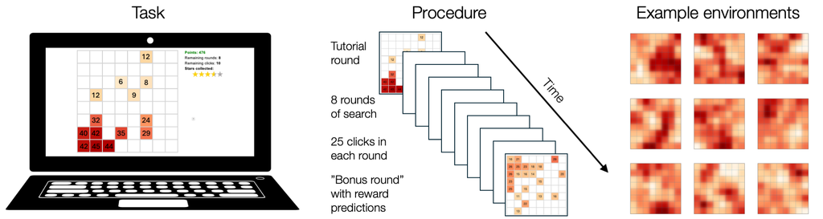

Screenshot from experiment, procedure and example environments

## 4.1 Materials and procedure

40 distinct environments were generated using a radial basis function kernel with $\lambda = 1$, creating a bivariate reward function on a grid that maps each tile location to a specific reward value. These reward functions gradually varied across the grid, creating environments with spatially-correlated rewards. The correlation between neighboring options is about *r*≈0.6, exponentially decreasing with distance.

Participants completed 10 rounds of the task, each featuring a new environment drawn without replacement from the set of 40 environments. In each round, participants had 25 choices to accumulate rewards. The first round served as a tutorial to familiarize participants with the task and was excluded from the analyses. The final round (round 10) was a bonus round where, after 15 choices, participants were asked to predict rewards for five unrevealed options. Data from this round were also excluded from the main analysis and analyzed separately.

At the start of each round, one tile was randomly revealed, and participants sequentially sampled 25 tiles. On each trial, they could choose to either click a new tile or re-click a previously selected tile. Selections were made by selecting the tile on the computer screen using a mouse, upon which they received a reward arbitrarily scaled to the range [0,50]. Re-clicked tiles showed small variations in reward due to normally distributed noise.

## 4.2 Sample

We collected data from adult participants with Parkinson’s disease (PD) who regularly receive Levodopa (levodopa) for symptomatic treatment (Abbott, 2010; Tambasco et al., 2018). Participants were recruited via a neurologist’s outpatient practice. Eligible participants were evaluated based on Hoehn-Yahr scores recorded in their patient files. The scale assesses disease severity and motor impairments based on a score from 1 to 5, with higher scores indicating greater severity (Goetz et al., 2004; Hoehn & Yahr, 1967). We limited recruitment to individuals with scores between 1 and 3, as scores of 4 and 5 reflect severe impairment.

PD patients were randomly assigned to two conditions: on medication (PD+) and off medication (PD-). In the PD+ group (N=34), patients’ scheduled levodopa was administered at least 30 minutes before the start of the experiment. In the PD- group (N=34), the next scheduled dose for participants was timed such that they were in a low dopamine state during the experiment, offering a clear contrast to the PD+ group. Thus, we refer to the ‘on medication’ condition as the state after taking levodopa and the ‘off medication’ condition as the state before their next scheduled dose.

The comparison group (N=35) consisted of individuals of similar age diagnosed with polyneuropathies (Control), a condition affecting the peripheral nervous system that can lead to physical symptoms such as pain, sensory loss, or motor weakness. However, unlike Parkinson’s disease, Control does not involve central dopaminergic dysfunction or cognitive impairment.

## 4.3 Clinical assessment

To characterize participants’ clinical status, we employed standardized measures assessing Parkinson’s disease severity, basic cognitive function, and depressive symptoms. PD severity was evaluated using the Hoehn-Yahr scale, which rates motor impairments such as postural instability and gait difficulties (Hoehn & Yahr, 1967). Participants can receive a score between one and five, with higher scores indicating more severe problems. Basic cognitive function of all participants was assessed through the Mini-Mental State Examination (MMSE), which is frequently used in in patients with dementia (Folstein et al., 1975). The test comprises 30 questions pertaining to different domains, including memory (e.g., recalling three objects), temporal and spatial orientation (e.g., date and location), and arithmetic ability. Finally, all participants answered the German version of the Beck Depression Inventory II, a self-report inventory consisting of 21 items measuring depressive symptoms (Beck et al., 1996; Hautzinger et al., 2006).

## 4.4 Sample characteristics

Table 1 shows the demographics of our sample, along with their Hoehn-Yahr, MMSE , and BDI scores. In the PD+ group, the mean time since their last levodopa dose was 104 min; in the PD- group it was 249min.

```r
# dat_sample %>%
#   group_by(group) %>%
#   summarise(n = n(),
#             female = sum(gender == "f"),
#             mean_age = mean(age),
#             sd_age = sd(age),
#             mean_BDI = mean(BDI, na.rm= T),
#             mean_MMSE = mean(MMSE, na.rm= T),
#             mean_HY = mean(hoehn_yahr, na.rm= T),
#             mean_time_since_ldopa = mean(time_since_ldopa,  na.rm= T)) %>%
#
#   kable(., format = "html", escape = FALSE, digits = 1) %>%
#   kable_styling("striped", full_width = FALSE)

# tbl_demographics <-
dat_sample %>%
  mutate(
    gender = factor(gender, levels = c("m","f"),
                    labels = c("Male","Female"))
  ) %>%
  select(group, gender, age, BDI, MMSE, hoehn_yahr, LEDD, time_since_ldopa) %>%
  tbl_summary(
    by = group,
    type = list(
      gender                                          ~ "categorical",
      c(age, BDI, MMSE, hoehn_yahr, LEDD, time_since_ldopa)  ~ "continuous"
    ),
    label = list(
      age        ~ "Age",
      hoehn_yahr ~ "PD severity (Hoehn-Yahr)",
      BDI        ~ "Depression (BDI)",
      LEDD        ~ "Levodopa EDD",
      time_since_ldopa        ~ "Time since medication (min)"
    ),
    statistic = list(
      all_categorical() ~ "{n} ({p}%)",
      all_continuous()  ~ "{mean} ({sd})"
    ),
    digits  = all_continuous() ~ 1,
    missing = "no"
  ) %>%
  add_p(
    # global ANOVA for continuous, chi-square for categorical
    test = list(
      all_continuous()   ~ "oneway.test",
      all_categorical()  ~ "chisq.test"
    )
  ) %>%
  modify_header(
    label   ~ "**Variable**",
    p.value ~ "**p-value**"
  ) %>%
  bold_labels()  %>%
  modify_fmt_fun( # replace  "NA (NA)" or "NA" with a dash
    all_stat_cols() ~ function(x) {
      x[x %in% c("NA (NA)", "NA")] <- " "
      x
    }
  ) %>%
  modify_header(label ~ "")
# GENERATE LATEX CODE
# as_gt(tbl_demographics) %>% gt::as_latex()
# as_kable_extra(tbl_demographics, format = "latex")
# as_kable(tbl, format = "latex")
```

Table 1: Demographics and clinical assessment.

|  | **PD-** N = 34<sup>1</sup> | **PD+** N = 34<sup>1</sup> | **Control** N = 35<sup>1</sup> | **p-value**<sup>2</sup> |
| --- | --- | --- | --- | --- |
| gender |  |  |  | 0.4 |
| Male | 19 (56%) | 16 (47%) | 14 (40%) |  |
| Female | 15 (44%) | 18 (53%) | 21 (60%) |  |
| Age | 67.0 (6.5) | 64.3 (6.3) | 65.5 (7.0) | 0.2 |
| Depression (BDI) | 8.6 (4.1) | 8.6 (3.6) | 8.5 (3.4) | >0.9 |
| MMSE | 28.8 (0.8) | 29.1 (0.8) | 28.8 (0.9) | 0.3 |
| PD severity (Hoehn-Yahr) | 1.9 (0.7) | 1.9 (0.6) |  | 0.9 |
| Levodopa EDD | 809.0 (230.8) | 894.0 (441.7) |  | 0.6 |
| Time since medication (min) | 248.5 (32.7) | 104.4 (59.2) |  | <0.001 |

<sup>1</sup> n (%); Mean (SD)  
<sup>2</sup> Pearson’s Chi-squared test; One-way analysis of means (not assuming equal variances)

# 5 Results

We compared PD patients on and off medication and age-matched controls in their ability to perform a spatial reward learning task. All PD patients regularly received dopaminergic medication (levodopa) for symptomatic treatment and were randomly assigned to be tested either after taking their regular dose (N=34) or in a state of dopaminergic depletion shortly before their next dose (N=34).

The control group consisted of age-matched patients with polyneuropathies, i.e. disorders or damage of the peripheral nerves without involvement of the central nervous system (N=35).

All three groups were of interest to our investigation. The comparison between PD- patients off medication and the control group indicates deficits specific to PD in a state of (natural) dopamine depletion. The comparison between PD patients off (PD-) and on medication (PD+) shows to what degree levodopa improves performance within PD. Finally, the comparison between PD patients on medication (PD+) and controls clarifies to what degree compensatory effects of levodopa align PD behavior to the control group.

## 5.1 Statistical analyses

To assess how well participants balanced the explore-exploit dilemma we analyzed behavior in terms of performance, temporal dynamics of exploration behavior, and spatial trajectories of search, based on eight rounds of 25 trials per participant. These analyses exclude the tutorial (round 1) and the “bonus round” (round 10) leaving a total of 200 search decisions (8 rounds $\times$ 25 trials) for each participant. Results of the bonus round, where we analyze participants’ reward predictions and confidence judgments, were analyzed sparately and are reported in the SI (Section 7.2.2). We report both frequentist statistics and Bayes factors ($BF$) to quantify the relative evidence of the data in favor of the alternative hypothesis ($H_1$) over the null hypothesis ($H_0$); see SI Section 7.1 for details and references. Various helper functions are implemented in *statisticalTests.R*. Regression analyses were performed in a Bayesian framework with *Stan*, accessed via R-package *brms*, complemented by frequentist hierarchical regression analyses (via package *lmer*).

```r
# show example data
head(dat %>%
       group_by(group) %>%
       slice_head(n=25)  %>%
       ungroup()) %>%
  kable("html", caption = "Example behavioral data.") %>%
  kable_styling(bootstrap_options = c("striped", "hover", "condensed"), full_width = FALSE) %>%
  scroll_box(width = "100%", height = "300px")
```

Table 2

Example behavioral data.

| id | age | gender | group | BDI | MMSE | hoehn_yahr | last_ldopa | next_ldopa | time_exp | time_since_ldopa | condition | LDD | LEDD | session | x | y | chosen | z | zscaled | time | trial | round | distance | type_choice | previous_reward | latency_ms |
| --- | --- | --- | --- | --- | --- | --- | --- | --- | --- | --- | --- | --- | --- | --- | --- | --- | --- | --- | --- | --- | --- | --- | --- | --- | --- | --- |
| 168 | 69 | f | PD- | 2 | 29 | 3 | 08:30:00 | 13:00:00 | 13:00:00 | 270 | PPD- |  |  | 1 | 4 | 3 | 29 | 0.22 | 13 | 1.723548e+12 | 0 | 1 |  |  |  |  |
| 168 | 69 | f | PD- | 2 | 29 | 3 | 08:30:00 | 13:00:00 | 13:00:00 | 270 | PPD- |  |  | 1 | 2 | 3 | 27 | 0.18 | 11 | 1.723548e+12 | 1 | 1 | 2 | Far | 0.22 | 3569 |
| 168 | 69 | f | PD- | 2 | 29 | 3 | 08:30:00 | 13:00:00 | 13:00:00 | 270 | PPD- |  |  | 1 | 1 | 1 | 10 | 0.32 | 17 | 1.723548e+12 | 2 | 1 | 3 | Far | 0.18 | 1132 |
| 168 | 69 | f | PD- | 2 | 29 | 3 | 08:30:00 | 13:00:00 | 13:00:00 | 270 | PPD- |  |  | 1 | 1 | 5 | 42 | 0.50 | 23 | 1.723548e+12 | 3 | 1 | 4 | Far | 0.32 | 1056 |
| 168 | 69 | f | PD- | 2 | 29 | 3 | 08:30:00 | 13:00:00 | 13:00:00 | 270 | PPD- |  |  | 1 | 5 | 1 | 14 | 0.32 | 17 | 1.723548e+12 | 4 | 1 | 8 | Far | 0.50 | 1307 |
| 168 | 69 | f | PD- | 2 | 29 | 3 | 08:30:00 | 13:00:00 | 13:00:00 | 270 | PPD- |  |  | 1 | 6 | 5 | 47 | 0.70 | 30 | 1.723548e+12 | 5 | 1 | 5 | Far | 0.32 | 1619 |

Example data.

## 5.2 Impaired reward learning in PD patients off medication

Hierarchical regression analyses revealed an effect of group on obtained rewards, but no effects of game round, PD severity, depressive symptoms, or cognitive functioning Section 7. These variables were therefore not considered in subsequent analyses.

```r
df_mean_reward_subject <- dat %>%
  filter(trial != 0 & round %in% 2:9) %>% # exclude first (randomly revealed) tile and practice round and bonus round
  group_by(id) %>%
  summarise(age = mean(age),
            group = first(group),
            sum_reward = sum(z),
            mean_reward = mean(z),
            sd_reward = sd(z),
            BDI = first(BDI),
            MMSE = first(MMSE),
            hoehn_yahr = first(hoehn_yahr))

# some summary stats for obtained mean rewards
# df_mean_reward_subject %>%
#   group_by(group) %>%
#   summarise(n = n(),
#             m_reward = mean(mean_reward),
#             md_reward = median(mean_reward),
#             var_reward = var(mean_reward),
#             sd_reward = sd(mean_reward),
#             se_reward = sd_reward / sqrt(n),
#             lower_ci_reward = m_reward - qt(1 - (0.05 / 2), n - 1) * se_reward,
#             upper_ci_reward = m_reward + qt(1 - (0.05 / 2), n - 1) * se_reward) %>%
#
#   kable(., format = "html", escape = FALSE, digits = 2) %>%
#   kable_styling("striped", full_width = FALSE)
```

### 5.2.1 Rewards by group

Figure 1 shows the overall performance of each group, based on each subject’s mean reward across all trials. Control participants achieved higher rewards than both PD patients on medication ($t(67)=2.6$, $p=.010$, $d=0.6$, $BF=4.5$) and off medication ($t(67)=7.5$, $p<.001$, $d=1.8$, $BF>100$). Notably, PD patients on medication achieved substantially higher rewards than patients off medication ($t(66)=5.9$, $p<.001$, $d=1.4$, $BF>100$), indicating as strong beneficial effect of levodopa on the ability to balance exploration and exploitation.

- PD+ vs. PD-: $t(66)=5.9$, $p<.001$, $d=1.4$, $BF>100$
- Control vs. PD-: $t(67)=7.5$, $p<.001$, $d=1.8$, $BF>100$
- Control vs. PD+:$t(67)=2.6$, $p=.010$, $d=0.6$, $BF=4.5$

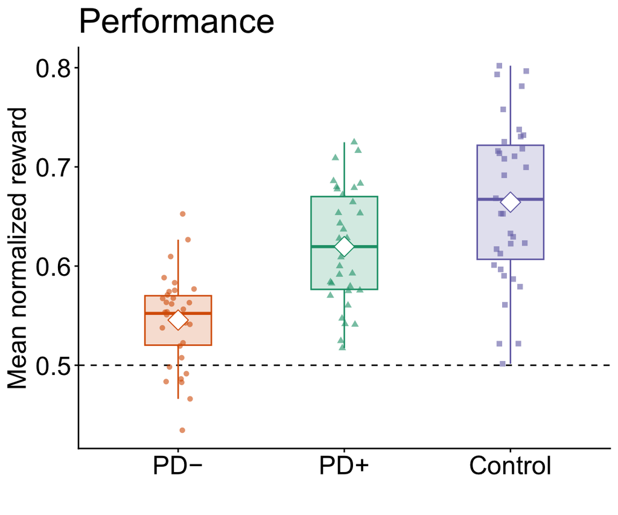

Figure 1: Obtained rewards by group. Each dot is one participants’ mean reward across all rounds and trials.

```r
# Boxplots of rewards by group
p_performance <- ggplot(df_mean_reward_subject, aes(x = group, y = mean_reward, color = group, fill = group, shape = group)) +
  geom_hline(yintercept=.5, linetype='dashed', color='black') + # random choice model (mean across all 40 environments)
  geom_boxplot(alpha = 0.2, outlier.shape = NA, width = 0.4) +
  geom_jitter(width = 0.1, size = 1.5, alpha = 0.6) +
  stat_summary(fun = mean, geom = "point", shape = 23, fill = "white", size = 5) +
  scale_color_manual(values = groupcolors) +
  scale_fill_manual(values = groupcolors) +
  ylab("Mean normalized reward") +
  scale_x_discrete(name = "", labels = grouplabels) +
  ggtitle("Performance") +
  theme_classic() +
  theme(
    legend.position = 'none',
    legend.title = element_blank(),
    plot.title = element_text(size=24),
    axis.text = element_text(size=18),
    axis.title = element_text(size=18)
  )

p_performance
# ggsave("plots/performance.png", p_performance, dpi=300, height = 5, width = 6 )

# Control vs. PD+
# ttestBF(subset(df_mean_reward_subject, group == 'Control')$mean_reward, subset(df_mean_reward_subject, group == 'PD+')$mean_reward, var.equal = TRUE)
# t.test(subset(df_mean_reward_subject, group == 'Control')$mean_reward, subset(df_mean_reward_subject, group == 'PD+' )$mean_reward, var.equal = T)

# Control vs. PD-
# ttestBF(subset(df_mean_reward_subject, group == 'Control')$mean_reward, subset(df_mean_reward_subject, group == 'PD-')$mean_reward, var.equal = TRUE)
# t.test(subset(df_mean_reward_subject, group == 'Control')$mean_reward, subset(df_mean_reward_subject, group == 'PD-' )$mean_reward, var.equal = T)

# PPD vs. PD-
# ttestBF(subset(df_mean_reward_subject, group == 'PD+')$mean_reward, subset(df_mean_reward_subject, group == 'PD-')$mean_reward, var.equal = TRUE)
# t.test(subset(df_mean_reward_subject, group == 'PD+')$mean_reward, subset(df_mean_reward_subject, group == 'PD-' )$mean_reward, var.equal = T)

# Plot for Computational Psychiatry Conference (Tübingen, July 2025)
# p_performance_by_group_CPP <- ggplot(df_mean_reward_subject, aes(x = group, y = mean_reward, color = group, fill = group, shape = group)) +
#   #geom_hline(yintercept=.5, linetype='dashed', color='red') + # random choice model (mean across all 40 environments)
#   geom_boxplot(alpha = 0.2, outlier.shape = NA, width = 0.5) +
#   geom_jitter(width = 0.15, size = 1.5, alpha = 0.8) +
#   stat_summary(fun = mean, geom = "point", shape = 23, fill = "white", size = 1.5) +
#   scale_color_manual(values = groupcolors) +
#   scale_fill_manual(values = groupcolors) +
#   ylab("Mean normalized reward") +
#   xlab("") +
#   ggtitle("Performance") +
#   theme_classic() +
#   theme(
#     strip.background = element_blank(),
#     strip.text = element_text(color = "black", size = 20),
#     legend.position = 'none',
#     legend.title = element_blank(),
#       plot.title = element_text(size=24),
#       axis.text = element_text(size=20),
#       axis.title = element_text(size=20)
#   )
#
# ggsave("plots/performance_by_group_CPP.png", p_performance_by_group_CPP, dpi=300, height = 5, width = 6 )
# ggsave("plots/performance_by_group_CPP.pdf", p_performance_by_group_CPP, height = 5, width = 6 )
```

### 5.2.2 Learning curves

Participants’ learning curves (Figure 2) show the average reward obtained in each trial across rounds. For both polyneuropathy patients (Control) and PD patients on medication (PD+), the mean rewards increased as the round progresses, suggesting they effectively balanced exploration and exploitation to maximize rewards. In stark contrast, PD patients off medication (PD-) showed no improvement across trials.

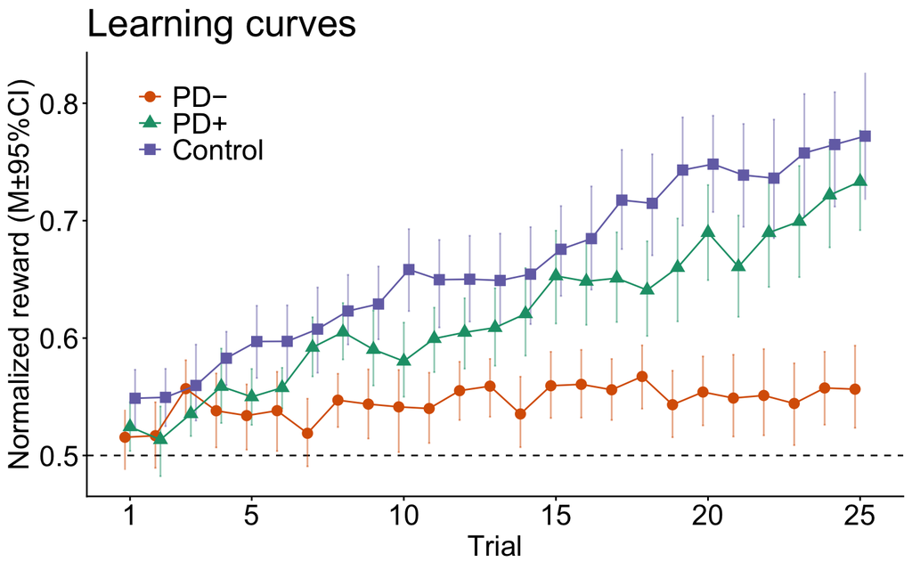

Figure 2: Learning curves, showing obtained mean reward for each trial, aggregated across rounds.

## 5.3 Levodopa mitigates deficits in exploration and exploitation

We determined for each trial whether the chosen tile was novel (an exploration decision) or had already been selected previously (an exploitation decision). Intuitively, at the beginning of each round learners should predominantly engage in exploration to identify high-reward options, and gradually shift toward exploitative behavior as they approach the end of the round.

```r
# proportion of unique choices per round per subject
df_unique_choices_round <-
  dat %>%
  filter(round %in% 2:9 & trial > 0) %>%
  group_by(id,group, round) %>%
  summarize(
    total = n(),  #  number of trials
    unique_tiles = n_distinct(x, y),  # unique (x, y) combinations (i.e., tiles)
    repeat_tiles = total - unique_tiles
  ) %>%
  mutate(prop_unique = unique_tiles/total,
         prop_repeat = repeat_tiles/total)


# proportion of unique choices across 8 rounds per subject
df_unique_choices_subject <- df_unique_choices_round %>%
  group_by(id, group) %>%
  summarize(m_prop_unique = mean(prop_unique),
            m_prop_repeat = mean(prop_repeat))

# means and CIs by group
df_unique_choices_subject %>%
  group_by(group) %>%
  summarize(
    mean_prop_unique  = mean(m_prop_unique, na.rm = TRUE),
    sd_prop_unique    = sd(m_prop_unique, na.rm = TRUE),
    ci_low_unique     = mean(m_prop_unique, na.rm = TRUE) - 1.96 * sd(m_prop_unique, na.rm = TRUE)/sqrt(n()),
    ci_high_unique    = mean(m_prop_unique, na.rm = TRUE) + 1.96 * sd(m_prop_unique, na.rm = TRUE)/sqrt(n()),
    mean_prop_repeat  = mean(m_prop_repeat, na.rm = TRUE),
    sd_prop_repeat    = sd(m_prop_repeat, na.rm = TRUE),
    ci_low_repeat     = mean(m_prop_repeat, na.rm = TRUE) - 1.96 * sd(m_prop_repeat, na.rm = TRUE)/sqrt(n()),
    ci_high_repeat    = mean(m_prop_repeat, na.rm = TRUE) + 1.96 * sd(m_prop_repeat, na.rm = TRUE)/sqrt(n())
  ) %>%
  knitr::kable(format = "html", escape = FALSE, digits = 2) %>%
  kableExtra::kable_styling("striped", full_width = FALSE)
```

| group | mean_prop_unique | sd_prop_unique | ci_low_unique | ci_high_unique | mean_prop_repeat | sd_prop_repeat | ci_low_repeat | ci_high_repeat |
| --- | --- | --- | --- | --- | --- | --- | --- | --- |
| PD- | 0.97 | 0.06 | 0.95 | 0.99 | 0.03 | 0.06 | 0.01 | 0.05 |
| PD+ | 0.84 | 0.13 | 0.80 | 0.89 | 0.16 | 0.13 | 0.11 | 0.20 |
| Control | 0.74 | 0.20 | 0.67 | 0.80 | 0.26 | 0.20 | 0.20 | 0.33 |

```r
dat <- dat %>%
  group_by(id, round) %>%
  arrange(trial, .by_group = TRUE) %>%  # Ensure data is sorted by trial
  mutate(
    is_new = factor(if_else(!duplicated(chosen), "new", "repeat")),  # Check uniqueness based on 'chosen' column
    is_new_label = factor(if_else(!duplicated(chosen), "Exploration", "Exploitation"), levels = c("Exploration", "Exploitation"))
  ) %>%
  ungroup() %>%
  mutate(is_new = if_else(trial == 0, NA, is_new))

dat_repeat_prop <- dat %>%
  filter(trial > 0 & round %in% 2:9) %>%
  group_by(id, group, trial) %>%
  summarize(
    prop_repeat = mean(is_new == "repeat", na.rm = TRUE)  # Calculate proportion of "repeat" (exploitation) choices
    # prop_new = mean(is_new == "new", na.rm = TRUE)  # Calculate proportion of "new" (exporation) choices
  )
```

### 5.3.1 Exploration and exploitation choices

Figure 3 shows that differences in reward accumulation are driven by learners’ ability to adequately balance exploration (selecting novel options) and exploitation (re-clicking tiles with known high rewards). PD patients tested on medication exploited more than patients off medication ($t(66)=5.0$, $p<.001$, $d=1.2$, $BF>100$), whose exploitation levels were notably low.

Controls exploited more than PD+ patients ($t(67)=2.6$, $p=.011$, $d=0.6$, $BF=4.3$), but the difference was less pronounced than the comparison of the PD groups, aligning with their slightly higher levels of reward accumulation.

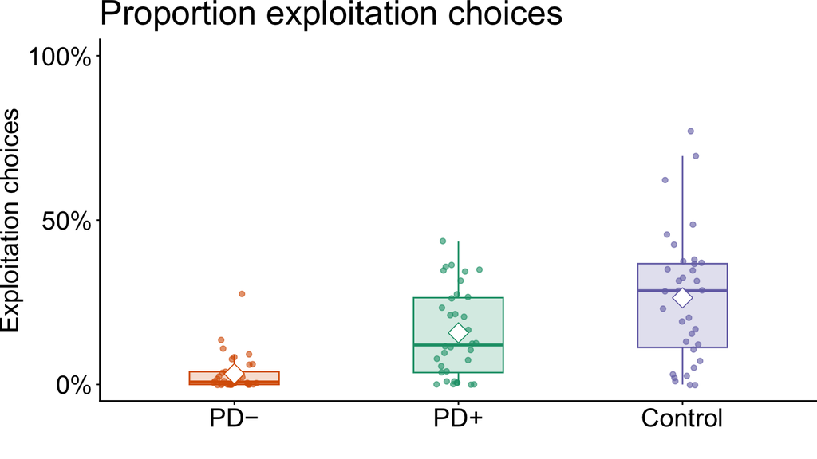

Figure 3: Balancing exploration and exploitation. Shown are the mean proportions of exploitation decisions, aggregated over trials and rounds. Each dot is one participant.

```r
p_explore_exploit_choices <-  ggplot(df_unique_choices_subject, aes(x = group, y = m_prop_repeat, color = group, fill = group)) +
  geom_boxplot(alpha = 0.2, width = 0.4, outlier.shape = NA) +
  geom_jitter(width = 0.1, size = 1.5, alpha= 0.6) +
  stat_summary(fun = mean, geom = "point", shape = 23, fill = "white", size = 5) +
  scale_color_manual(values = groupcolors, labels = grouplabels) +
  scale_fill_manual(values = groupcolors, labels = grouplabels) +
  scale_y_continuous("Exploitation choices",
                     breaks = c(0, 0.5, 1),
                     labels = percent_format(accuracy = 1)) +
  coord_cartesian(ylim = c(0, 1)) +
  scale_x_discrete(name = "", labels = grouplabels) +
  ggtitle("Proportion exploitation choices") +
  theme_classic() +
  theme(
    strip.background = element_blank(),
    strip.text = element_text(color = "black", size = 12),
    legend.position = "none",
    axis.title = element_text(size = 18),
    axis.text = element_text(size = 18),
    plot.margin = margin(0, 0, 0, 0),
    plot.title = element_text(size = 24)
  )

p_explore_exploit_choices
# ggsave("plots/explore_exploit_choices.png", p_explore_exploit_choices, dpi=300, width = 6, height = 5)
```

### 5.3.2 Exploration and exploitation over time

Mirroring the reward learning curves, controls and PD$+$ patients shifted more efficiently from exploring novel options to exploiting known options over time Figure 4. Controls began exploiting earlier in the round and exhibited a stronger overall tendency toward exploitation compared to PD$+$ patients, explaining their relative performance advantage. In stark contrast, PD$-$ patients predominantly engaged in exploration and showed only a weak tendency toward exploitation as the search horizon approached its end.

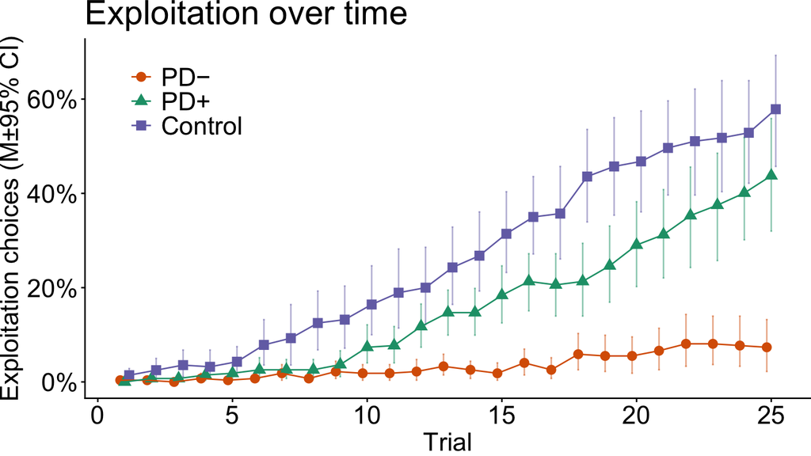

Figure 4: Mean proportion of exploitation decisions per trial, aggregated over rounds.

```r
# Main plot
p_explore_exploit_choices_over_time <- ggplot(dat_repeat_prop, aes(x = trial, y = prop_repeat, fill = group, shape = group, color = group)) +
  stat_summary(fun.data = mean_cl_boot, geom = "errorbar", width = 0.2, alpha = 0.5, position=position_dodge(width=0.5)) +
  stat_summary(fun = mean, geom = "point", size = 3, position=position_dodge(width=0.5)) +
  stat_summary(fun = mean, geom = "line", position=position_dodge(width=0.5)) +
  scale_fill_manual(values = groupcolors, labels = grouplabels) +
  scale_color_manual(values = groupcolors, labels = grouplabels) +
  scale_shape_manual(values = c(16, 17, 15), labels = grouplabels) +
  scale_y_continuous(labels = percent_format(accuracy = 1)) +
  labs(
    x = "Trial",
    y = "Exploitation choices (M±95% CI)",
    title = "Exploitation over time"
  ) +
  theme_classic() +
  theme(strip.background = element_blank(),
        strip.text = element_text(color = "black", size=12),
        # legend.position = c(0.01, 0.4),
        legend.position = "inside",
        legend.position.inside = c(0.05, 0.95),
        legend.justification = c(0, 1),
        legend.title = element_blank(),
        axis.title = element_text(colour="black",size = 18),
        axis.text = element_text(colour="black",size = 18),
        plot.margin = margin(0, 0, 0, 0),
        plot.title = element_text(size = 24),
        legend.text = element_text(colour="black", size=18)
  )


p_explore_exploit_choices_over_time
# ggsave("plots/explore_exploit_choices_over_time.png", p_explore_exploit_choices_over_time, dpi=300, width = 8, height = 4.5)
```

### 5.3.3 Rewards obtained from exploration and exploitation

```r
# mean reward
df_reward_explore_exploit <- dat %>%
  filter(round %in% 2:9 & trial > 0) %>%
  # group_by(id,group, round, is_new) %>%
  group_by(id,group, is_new_label) %>%
  summarize(
    n = n(),  #  number of trials
    mean_reward = mean(z)
  )

#table(df_reward_explore_exploit$group, df_reward_explore_exploit$is_new_label)

df_reward_explore_exploit %>%
  group_by(group, is_new_label) %>%
  summarize(
    n_participants = n(),
    mean_reward_group = mean(mean_reward, na.rm = TRUE),
    sd_reward_group = sd(mean_reward, na.rm = TRUE),
    .groups = "drop"
  ) %>%
  kable(format = "html", escape = F, digits=2) %>%
  kable_styling("striped", full_width = F)
# number of subjects per group and choice type; some subjects never made any exploit choices
df_proportion <- df_reward_explore_exploit %>%
  group_by(group, is_new_label) %>%
  summarize(n_participants = n(), .groups = "drop") %>%
  # compute total participants per group
  left_join(
    df_reward_explore_exploit %>%
      group_by(group) %>%
      summarize(total_participants = n_distinct(id), .groups = "drop"),
    by = "group"
  ) %>%
  mutate(prop = n_participants / total_participants)

df_reward_explore_exploit_full <- dat %>%
  filter(round %in% 2:9 & trial > 0) %>%
  group_by(id, group, is_new_label) %>%
  summarize(
    n = n(),
    mean_reward = mean(z),
    .groups = "drop"
  ) %>%
  group_by(id, group) %>%
  complete(is_new_label = c("Exploration", "Exploitation"),
           fill = list(n = 0, mean_reward = NA)) %>%
  ungroup()

df_reward_subset_both_explot_explore <- df_reward_explore_exploit_full %>%
  group_by(id) %>%
  filter(all(n[is_new_label %in% c("Exploration", "Exploitation")] > 0))

# table(df_reward_explore_exploit_full$group, df_reward_explore_exploit_full$is_new_label)

# ggplot(df_reward_explore_exploit, aes(x = group, y = mean_reward, color = group, fill = group, shape = group)) +
#   facet_wrap(~is_new_label) +
#   geom_boxplot(alpha = 0.2, size = 0.5, outlier.shape = NA, width=0.75) +
#   geom_jitter(width = 0.1, size = 0.8, alpha = 0.6) +
#   stat_summary(fun = mean, geom = "point", shape = 23, fill = "white", size = 1.5) +
#   scale_color_manual(values = groupcolors) +
#   scale_fill_manual(values = groupcolors) +
#   scale_y_continuous("Mean reward") +
#                    #breaks = c(0, 10, 20, 30, 40, 50),
#                    #labels = c("0","10","20","30","40","50"),
#                    #limits = c(0, 55)) +
#   scale_x_discrete(name = "", labels = grouplabels) +
#   ggtitle("Mean rewards for exploration and exploitation") +
#   theme_classic() +
#   theme(
#     strip.background = element_blank(),
#     strip.text = element_text(color = "black", size = 14),
#     legend.position = "none",
#     axis.title = element_text(size = 14),
#     axis.text = element_text(size = 14),
#     # plot.margin = margin(0, 0, 0, 0),
#     plot.title = element_text(size = 16)
#   )

# ggsave("plots/explore_exploit_choices_rewards.png", dpi=300, width = 7, height = 5)
# ggsave("plots/explore_exploit_choices_rewards.pdf", width = 7, height = 5)

# Analysis including all subjects, meaning that subjects who never exploited are still considered in the explore decisions:
#
# _Explore choices_
#
# - Control vs. PD+: `r ttestPretty(subset(df_reward_explore_exploit, group == 'Control' & is_new_label == "Exploration")$mean_reward, subset(df_reward_explore_exploit, group == 'PD+' & is_new_label == "Exploration")$mean_reward, var.equal = TRUE)`
# - Control vs. PD-: `r ttestPretty(subset(df_reward_explore_exploit, group == 'Control' & is_new_label == "Exploration")$mean_reward, subset(df_reward_explore_exploit, group == 'PD-' & is_new_label == "Exploration")$mean_reward, var.equal = TRUE)`
# - PD+ vs. PD-: `r ttestPretty(subset(df_reward_explore_exploit, group == 'PD+' & is_new_label == "Exploration")$mean_reward, subset(df_reward_explore_exploit, group == 'PD-' & is_new_label == "Exploration")$mean_reward, var.equal = TRUE)`
#
#
# _Exploit choices_
#
# - Control vs. PD+: `r ttestPretty(subset(df_reward_explore_exploit, group == 'Control' & is_new_label == "Exploitation")$mean_reward, subset(df_reward_explore_exploit, group == 'PD+' & is_new_label == "Exploitation")$mean_reward, var.equal = TRUE)`
# - Control vs. PD-: `r ttestPretty(subset(df_reward_explore_exploit, group == 'Control' & is_new_label == "Exploitation")$mean_reward, subset(df_reward_explore_exploit, group == 'PD-' & is_new_label == "Exploitation")$mean_reward, var.equal = TRUE)`
# - PD+ vs. PD-: `r ttestPretty(subset(df_reward_explore_exploit, group == 'PD+' & is_new_label == "Exploitation")$mean_reward, subset(df_reward_explore_exploit, group == 'PD-' & is_new_label == "Exploitation")$mean_reward, var.equal = TRUE)`
```

Table 3: Mean rewards for explore versus exploit choices, averaged across all rounds and trials per participant. Each dot represents one participant.

| group | is_new_label | n_participants | mean_reward_group | sd_reward_group |
| --- | --- | --- | --- | --- |
| PD- | Exploration | 34 | 0.54 | 0.04 |
| PD- | Exploitation | 22 | 0.70 | 0.25 |
| PD+ | Exploration | 34 | 0.56 | 0.02 |
| PD+ | Exploitation | 30 | 0.90 | 0.14 |
| Control | Exploration | 35 | 0.57 | 0.04 |
| Control | Exploitation | 33 | 0.91 | 0.15 |

Group comaprisons including only subjects who engaged at least once in each choice type:

*Explore choices*

- PD+ vs. PD-: $t(50)=2.5$, $p=.016$, $d=0.7$, $BF=3.3$
- Control vs. PD-: $t(53)=3.0$, $p=.004$, $d=0.8$, $BF=10$
- Control vs. PD+: $t(61)=1.1$, $p=.279$, $d=0.3$, $BF=.43$

*Exploit choices*

- PD+ vs. PD-: $t(50)=3.6$, $p<.001$, $d=1.0$, $BF=38$
- Control vs. PD-: $t(53)=3.9$, $p<.001$, $d=1.1$, $BF=83$
- Control vs. PD+: $t(61)=0.4$, $p=.697$, $d=0.1$, $BF=.27$

## 5.4 Levodopa restores reward sensitivity during exploration

We analyzed the spatial trajectory of the individual search trajectories on the task, quantifying step‐by‐step distances and testing how obtained rewards shaped subsequent choices.

### 5.4.1 Distance of consecutive choices

Figure 5 shows the distribution of distances among consecutive clicks, illustrating how participants explored the space. In all groups, the most frequent choice was to click on a directly neighboring tile (distance=1), indicating a localized search strategy. This locality bias was strongest in PD$-$ patients off medication, who most frequently selected directly neighboring tiles. Across all choices, controls had lower search distances than both PD$+$ patients on medication and PD$-$ patients off medication. The mean distance of the two PD groups did not differ, but the distributions indicate different underlying strategies: fewer repeats (distance 0) but more near choices (distance 1) in PD$-$ patients, balancing out against PD$+$ patients who made more exploit choices but clicked less often on directly neighboring tiles. Simulations of a random learner show a very different pattern compared to human behavior, indicating that all groups deviated substantially from purely random exploration.

```r
#  distance by participant
df_mean_distance_subject <- dat %>%
  filter(trial > 0 & round %in% 2:9) %>%
  group_by(id, group) %>%
  summarise(decisions=n(),
            mean_distance = mean(distance, na.rm = TRUE),
            median_distance = median(distance),
            SD_distance = sd(distance),
            SE_distance = SD_distance / sqrt(decisions)) %>%
  ungroup()

#  distance by group
df_mean_distance <-
  df_mean_distance_subject %>%
  group_by(group) %>%
  summarise(
    n                     = n(),
    m         = mean(mean_distance, na.rm = TRUE),
    md       = median(mean_distance, na.rm = TRUE),
    sd           = sd(mean_distance,   na.rm = TRUE),
    se           = sd / sqrt(n),
    .groups = "drop"
  )

# df_mean_distance %>%
#   kable(format = "html", escape = F, digits=2) %>%
#   kable_styling("striped", full_width = F)

df_props <-
  dat %>%
  filter(trial > 0, round %in% 2:9) %>%
  group_by(group, distance) %>%
  summarise(count = n(), .groups = "drop_last") %>%
  mutate(type_choice = if_else(distance == 0, "Repeat", "Exploration")) %>%
  mutate(prop = count / sum(count))
```

- PD+ on medication vs. PD- off medication: $t(66)=-0.3$, $p=.757$, $d=0.1$, $BF=.26$
- Control vs. PD- off medication: $t(67)=-2.3$, $p=.023$, $d=0.6$, $BF=2.4$
- Control vs. PD+ patients on medication: $t(67)=-2.6$, $p=.011$, $d=0.6$, $BF=4.2$

```r
# simulate consecutive search distances for learner choosing randomly on each step
# each learner chooses with uniform probability among the 8x8=64 options
# first tile (option) chosen randomly, then 25 random choices by the learner
# analyzed is the consecutive distance among choices

simulate_learner <- function(n_trial = 26, grid_size = 8) {
  # random sequence of choices (positions on 8x8 grid)
  x <- sample(1:grid_size, n_trial, replace = TRUE)
  y <- sample(1:grid_size, n_trial, replace = TRUE)

  # trial index: 0 is randomly revelead trial, then 25 trials by learner
  trial <- 0:(n_trial - 1)

  # data frame
  path <- data.frame(trial = trial, x = x, y = y)

  # Manhattan distance between consecutive choices
  path$distance <- c(NA, abs(diff(path$x)) + abs(diff(path$y)))

  return(path)
}

# number of learners
n_learners <- 10^4
simulations <- lapply(1:n_learners, function(i) simulate_learner())

# bind results
simulations_df <- do.call(rbind, lapply(seq_along(simulations), function(i) {
  cbind(learner = i, simulations[[i]])
}))

# exploration (consecutive distance > 0) vs. exploitation (consecutive distance == 0) decisions
df_props_simulated <-
  simulations_df %>%
  filter(trial > 0) %>%
  group_by(distance) %>%
  summarise(count = n()) %>%
  mutate(prop = count / sum(count)) %>%
  mutate(group = "Random")

# mean(simulations_df$distance, na.rm = T)
```

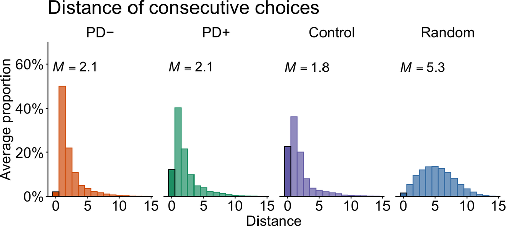

Figure 5: Distance among consecutive clicks.

### 5.4.2 Distance as function of previous reward

Finally, we analysed the relation between the value of a reward obtained at time $t$ and the search distance on the subsequent trial $t+1$. If a large reward was obtained, searchers should search more locally, while conversely, if a low reward was obtained, searchers should be more likely to search farther away.

Across all trials and rounds, search distance and previous reward were negatively correlated, indicating that participants tended to search further away following lower rewards compared to higher rewards. This relationship was stronger in Control patients ($r=-.43$, $p<.001$, $BF>100$) and PD+ patients ($r=-.34$, $p<.001$, $BF>100$) compared to PD- patients ($r=-.16$, $p<.001$, $BF>100$). These findings suggest that PD patients off medication exhibited less adaptive search behavior than those on medication and individuals with polyneuropathies.

```r
# correlation of previous reward and distance of consecutive choices, by age group and environment
# overall, ignoring within-subject factor
# dat %>%
#   filter(trial != 0 & round %in% 2:9) %>% # exclude first (randomly revealed) tile and practice round and bonus round
#   group_by(group) %>%
#   summarise(corTestPretty(previous_reward, distance))

# mean correlation between distance and reward obtained on previous step
# first aggregated within each round and then within each subject
# such that there is one correlation for each subject

# reward_distance_cor <- dat %>%
#   filter(trial != 0 & round %in% 2:9) %>% # exclude first (randomly revealed) tile and practice round and bonus round
#   group_by(id, round, group) %>%
#   summarise(cor = cor(previous_reward, distance)) %>%
#   mutate(cor = replace_na(cor, 0)) %>%  # in some rounds subjects clicked the same tile throughout; set cor=0
#   ungroup() %>%
#   group_by(id, group) %>%
#   summarise(mean_cor = mean(cor))

# mean correlation between distance and reward obtained on previous step as function of group
# reward_distance_cor %>%
#   group_by(group) %>%
#   summarise(n = n(),
#             m_cor = mean(mean_cor),
#             SD_cor = sd(mean_cor),
#             se_cor = SD_cor / sqrt(n),
#             lower_ci_cor = m_cor - qt(1 - (0.05 / 2), n - 1) * se_cor,
#             upper_ci_cor = m_cor + qt(1 - (0.05 / 2), n - 1) * se_cor)

#plot regression lines based on raw data
# ggplot(subset(dat, trial > 0 & round %in% 2:9), aes(x = previous_reward, y = distance, color = group)) +
#   facet_wrap(~group) +
#   geom_jitter(alpha = 0.3, width = 0.1, height = 0.1) +
#   geom_smooth(method = "lm", formula = y ~ x, se = TRUE) +
#
#   ggtitle("Regression Lines for Distance by Previous Reward and Group") +
#   theme_minimal() +
#   xlab("Previous Reward") +
#   ylab("Distance")
```

Given the nested structure of the data, we next employed a Bayesian hierarchical regression analysis to predict search distance based on the reward obtained in the previous step, with group and their interaction as population-level (fixed) effects and subject-wise random intercepts. These analyses show that both the magnitude of reward obtained on the last step and group influence search distance. Notably, PD patients off medication (PD-) adapted their search behavior less in response to reward magnitude, while patients on medication (PD+) exhibited adaptation levels close to controls (Figure 6 and Table 4).

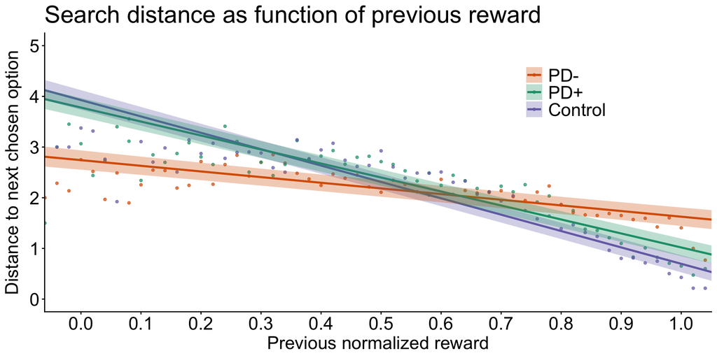

Figure 6: Bayesian hierarchical regression analysis with search distance as function of previous reward. Dots are the empirical mean distances for each reward value, aggregated over participants, trials, and rounds.

```r
# Bayesian regression analysis
# run_model() is a wrapper for brm models such that it saves the full model the first time it is run, otherwise it loads it from disk from directory `~brm`
# Fixed effects: previous_reward and group.
# random intercept for each participant
brm_distance_reward <- run_model(brm(distance ~ previous_reward * group + (1|id),
                                     data=subset(dat, trial > 0 & round %in% 2:9 ),
                                     cores=4,
                                     chains=4,
                                     backend = "cmdstanr",
                                     seed = 0815,
                                     iter = 5000,
                                     warmup=1000,
                                     control = list(adapt_delta = 0.99, max_treedepth = 15)),
                                 #prior = prior(normal(0,10), class = "b")),
                                 modelName = 'brm_distance_reward')

# create HTML table
#tab_model(brm_distance_reward, bpe="mean", title = "Bayesian regression results: Search distance as function of reward on previous step.")

# describe_posterior(
#   brm_distance_reward,
#   centrality = "mean",
#   ci = 0.95,
#   test = "p_direction"
# ) %>%
# kable(caption = "Bayesian regression: Search distance ~ previous reward")

# model diagnostics
# summary(brm_distance_reward)
# plot(brm_distance_reward)
# print_html(parameters:::parameters(brm_distance_reward))
#
# brm_distance_reward$diagnostics$divergent__
# fixef(brm_distance_reward)
# draws <- as_draws_df(brm_distance_reward)
# mean(draws$b_previous_reward > 0)   # probability slope > 0
# mean(draws$b_previous_reward < 0)   # probability slope < 0

# plot effect of previuos reward on subsequent search distance
#conditional_effects(brm_distance_reward, effects = "previous_reward:group")
#bayes_R2(brm_distance_reward)

# generate plot manually  predictions (otherwise difficult to plot the mean empirical values per geom_point)
# prevReward <-  seq(-3,55) / 50 # normalized reward

prevReward <-  seq(round(min(dat$previous_reward, na.rm=T),1),round(max(dat$previous_reward, na.rm=T),1), 0.1) # normalized reward

group  <-  levels(dat$group)
newdat <-  expand.grid(previous_reward=prevReward, group=group)

# predict distance based on previous reward
preds <-  fitted(brm_distance_reward, re_formula=NA, newdata=newdat, probs=c(.025, .975))
predsDF <-  data.frame(previous_reward=rep(prevReward, 3),
                       group=rep(levels(dat$group), each=length(prevReward)),
                       distance=preds[,1],
                       lower=preds[,3],
                       upper=preds[,4])

# average distance
grid  <-  expand.grid(x1=0:7, x2=0:7, y1=0:7, y2=0:7)
grid$distance <-  NA

for(i in 1:dim(grid)[1]){
  grid$distance[i] <- dist(rbind(c(grid$x1[i], grid$x2[i]), c(grid$y1[i], grid$y2[i])), method = "manhattan")
}

meanDist  <-  mean(grid$distance)

# plot predictions
p_regression_distance_reward <-
  ggplot() +
  stat_summary(dat, mapping=aes(x=previous_reward, y=distance, color=group, fill=group), fun=mean, geom='point', alpha=0.7, size=1, na.rm=T)+
  geom_line(predsDF, mapping=aes(x=previous_reward, y=distance, color=group), linewidth=1) +
  geom_ribbon(predsDF, mapping=aes(x=previous_reward, y=distance, ymin=lower, ymax=upper, fill=group), alpha=.3) +
  #geom_hline(yintercept=meanDist, linetype='dashed', color='red') + # mean distance
  # xlab('Normalized Previous Reward')+
  coord_cartesian(ylim= c(0,5), xlim= c(-0.01,1)) +
  scale_x_continuous(
    name = "Previous normalized reward",
    breaks = seq(0, 1, 0.1),
    labels = sprintf("%.1f", seq(0, 1, 0.1))) +
  scale_y_continuous(name = 'Distance to next chosen option', breaks = seq(0,5,1), labels = c(" 0"," 1"," 2"," 3"," 4"," 5"))+
  scale_fill_manual(values=groupcolors) +
  scale_color_manual(values=groupcolors) +
  labs(
    title = "Search distance as function of previous reward",
    #subtitle = "(Bayesian hierarchical regression)"
  ) +
  theme_classic() +
  theme(legend.position = "inside",
        legend.position.inside = c(0.85, 0.9),
        legend.justification = c(1, 1),
        legend.title = element_blank(),
        legend.text = element_text(colour = "black", size = 18),
        plot.title = element_text(colour = "black", size = 24),
        plot.subtitle = element_text(colour = "black", size = 18),
        axis.text = element_text(colour = "black", size = 18),
        axis.title = element_text(colour = "black", size = 18)
  )

p_regression_distance_reward
# ggsave("plots/regression_distance_reward_brms.png", p_regression_distance_reward, dpi=300, height=5, width=7)
# ggsave("plots/regression_distance_reward_brms.pdf", p_regression_distance_reward, height=5, width=7)
```

```r
# create HTML table
tab_model(brm_distance_reward, bpe="mean")
```

Table 4: Bayesian regression results: Search distance as function of reward on previous step.

|  | distance |  |
| --- | --- | --- |
| Predictors | Estimates | CI (95%) |
| Intercept | 2.74 | 2.55 – 2.93 |
| previous reward | -1.12 | -1.30 – -0.93 |
| groupPDP | 1.04 | 0.77 – 1.30 |
| group: Control | 1.19 | 0.92 – 1.46 |
| previous_reward:groupPDP | -1.64 | -1.90 – -1.39 |
| previous_reward:groupControl | -2.11 | -2.37 – -1.87 |
| Random Effects |  |  |
| σ<sup>2</sup> | 0.21 |  |
| τ<sub>00</sub> | 3.74 |  |
| ICC | 0.05 |  |
| N <sub>id</sub> | 103 |  |
| Observations | 20600 |  |
| Marginal R<sup>2</sup> / Conditional R<sup>2</sup> | 0.117 / 0.170 |  |

## 5.5 The Gaussian Process Upper Confidence Bound (GP-UCB) model captures key behavioral aspects of exploration and generalization

The behavioral analyses showed that individuals in a dopamine-depleted state exhibit a severe deficit in balancing exploration and exploitation. By contrast, the behavior of patients on medication was markedly improved and largely resembled controls. The increased exploration in patients off medication could result from more random choice behavior, an increased emphasis on uncertainty-directed exploration, or from impaired generalization reducing the ability to use information from one option to guide choices.

To disentangle these mechanisms, we used the Gaussian Process Upper Confidence Bound (GP-UCB) model (see Methods for formal specification). The model integrates similarity-based generalization with two distinct exploration mechanisms: uncertainty-directed exploration, which seeks to reduce uncertainty about rewards, and random exploration, which adds stochastic noise without being directed towards a particular goal (Wu et al., 2018; Wu et al., 2025). These processes are captured by three key parameters: the generalization parameter $\lambda$, which determines how strongly rewards are generalized across options; the uncertainty bonus $\beta$, which governs the degree of uncertainty-directed exploration by determining the value given to uncertainty; and the temperature parameter $\tau$, which captures random exploration through choice variability.

In previous research using the same experimental paradigm, this model provided the best account of exploratory behavior in healthy participants (Giron et al., 2023; Meder et al., 2021; Schulz et al., 2019; Witt et al., 2024; Wu et al., 2018; Wu et al., 2020). Importantly, by decomposing exploration into generalization ($\lambda$), uncertainty-driven exploration ($\beta$), and random exploration ($\tau$), the model allows us to identify which mechanisms are altered by PD and medication. This approach builds on prior findings that levodopa impairs discrimination learning while sparing generalization in PD (Shohamy et al., 2006), that levodopa reduces directed exploration in healthy participants (Chakroun et al., 2020), and that PD disrupts the overall exploration-exploitation balance (Djamshidian et al., 2011; Gilmour et al., 2024; Seymour et al., 2016).

The GP-UCB model comprises three components: a learning model, which uses Bayesian inference to generate predictions about the rewards associated with each option (tiles); a sampling strategy, which uses both the reward expectations and the uncertainty about this expectation to evaluate options; and a choice rule, which maps the valuation of options onto choice probabilities (see Methods for formal specification).

### 5.5.1 Learning model: Gaussian Process (GP) generalization

The similarity-based learning mechanism is implemented by a Gaussian Process (GP) (Schulz et al., 2018; Williams & Rasmussen, 2006), which learns an unknown spatial value function from noisy observations (e.g., a mapping from spatial location to expected reward). The amount of generalization depends on the similarity of options, where similarity is defined as spatial proximity: options that are closer to each other are assumed to be more alike (i.e., yield similar rewards) than options that are further away. The degree to which learning about one location influences reward expectations of other locations is governed by the parameter $\lambda$, indicating how strongly a learner extrapolates from known rewards to other locations. Higher values of $\lambda$ imply stronger generalization, whereas lower values correspond to weaker generalization.

Formally, a GP defines a probability distribution over functions mapping inputs to outputs $f: \mathcal{X} \rightarrow Y$. In our case, these functions map grid locations $\mathbf{x}\in \mathcal{X}$ to scalar reward observations $y \in Y$, with the prior distribution taking the form of a multivariate Gaussian:

$$f \sim \mathcal{GP}\big(m(\mathbf{x}),\, k(\mathbf{x}, \mathbf{x}')\big).
\tag{1}$$

The GP is fully specified by prior mean function $m(\mathbf{x})$ defining the prior expectations of each input, and a kernel (covariance) $k(\mathbf{x}, \mathbf{x}')$ encoding how strongly rewards at two locations are expected to covary as a function of their distance (Equation 2). Without loss of generality, we set the prior mean to zero (Williams & Rasmussen, 2006) and use the common radial basis function (RBF) kernel:

$$k(\mathbf{x}, \mathbf{x}') = \exp\left(-\frac{||\mathbf{x}-\mathbf{x}'||^2}{2\lambda^2}\right).
\tag{2}$$

Here, $\mathbf{x}$ and $\mathbf{x}'$ are the coordinates of two tiles on the grid, and $\lambda$ is the length-scale parameter, which governs the amount of generalization (i.e., the smoothness of the function). Higher values of $\lambda$ imply smoother functions, leading to stronger expectations regarding reward correlations. Lower values of $\lambda$ entail rougher functions, i.e. less correlation among similar options. %As $\lambda \to \infty$, the RBF kernel assumes functions approaching linearity; as $\lambda \to 0$, there ceases to be any spatial correlation, meaning that learning of options’ rewards happens independently. In our analyses, we treat $\lambda$ as a free parameter representing the extent to which learners generalize rewards as function of spatial proximity.

To compute posterior predictions for any target location $\mathbf{x}_\star$, we condition the model on a set of observations $\mathcal{D}_t=\{X_{t}, \textbf{y}_{t}\}$ of choices $X_{t} = [\mathbf{x}_1, \ldots \mathbf{x}_t]$ and corresponding reward observations $\mathbf{y}_t = [y_1, \ldots, y_t]$ at time $t$. This posterior also takes the form of a multivariate Gaussian:

$$f(\mathbf{x}_\star) \mid \mathcal{D}_t \sim \mathcal{N}(m(\mathbf{x}_\star|\mathcal{D}_t), v(\mathbf{x}_\star|\mathcal{D}_t)),
\tag{3}$$

which is entirely defined by a posterior mean

$$m(\mathbf{x}_\star|\mathcal{D}_t)
\tag{4}$$

These are computed as:

$$m(\mathbf{x}_\star|\mathcal{D}_t) = \mathbf{k}_\star \big[ K_{X,X} + \sigma_\epsilon^2 I \big]^{-1} \mathbf{y}_t
\tag{5}$$

$$\sigma^2(\mathbf{x}_\star|\mathcal{D}_t) = k(\mathbf{x}_\star,\mathbf{x}_\star) - \mathbf{k}_\star^\top \big[ K_{X,X} + \sigma_\epsilon^2 I \big]^{-1} \mathbf{k}_\star
\tag{6}$$

Here, $\mathbf{k}_\star=[k(\mathbf{x}_1,\mathbf{x_\star}), \ldots, k(\mathbf{x}_t,\mathbf{x_\star})]$ is the vector of kernel similarities between past observations and the target location, $K_{X,X}$ is a matrix of pairwise kernel similarities between all past observations in $X_t$, $I$ is a $t \times t$ identity matrix, and $\sigma_\epsilon^2$ is the observation noise capturing the stochasticity of reward observations and is fixed to the true reward variability of each arm of the bandit $\sigma_\epsilon^2=.0001$.

### 5.5.2 Sampling strategy: Balancing rewards and uncertainty through Upper Confidence Bound sampling

Options are valued according to Upper Confidence Bound (UCB) sampling, which considers both reward expectations and the associated uncertainty (Auer, 2002). UCB sampling implements a form of uncertainty-directed exploration that balances exploiting high rewards and seeking information. Uncertainty is valued positively to promote exploration of underexplored options, with the strength of this uncertainty bonus represented by the parameter $\beta$.

$$\text{UCB}(\mathbf{x})= m(\mathbf{x}|\mathcal{D}_t)+\beta\sqrt{v(\mathbf{x}_\star|\mathcal{D}_t)}
\tag{7}$$

where the expected reward of an option $m(\mathbf{x}|\mathcal{D}_t)$ captures its exploitation value, and the scaled uncertainty$\beta\sqrt{v(\mathbf{x}_\star|\mathcal{D}_t)}$ captures its exploration value, with $\beta$ modulating how much exploration is promoted relative to exploitation. Higher values of $\beta$ reflect a stronger drive to explore uncertain options, while lower values reflect a preference for exploiting known high-reward options.

### 5.5.3 Choice rule: Translating value into action

After computing UCB values for each option, the model does not always pick the most valuable one. Instead, it samples probabilistically using a softmax choice function, which adds random decision noise to the choice process:

This is implemented using a softmax function:

$$p(\mathbf{x}) = \frac{\exp(\text{UCB}(\mathbf{x})/\tau)}{\sum_{j=1}^{N}\exp(\text{UCB}(\mathbf{x}_j)/\tau)}.
\tag{8}$$

The amount of randomness in the choice probabilities is governed by the *temperature parameter* $\tau$. Higher values of $\tau$ make the choice probabilities more uniform, such that the choice behavior is less influenced by options’ UCB values and more random. Lower value of $\tau$ imply that the learner is more sensitive to options’ UCB values, making them increasingly likely to be selected. In the limits, if $\tau \rightarrow 0$, choice behavior reduces to a greedy mean policy that always selects the option with the highest value (pure exploitation), and if $\tau \rightarrow \infty$ all options are chose with equal probability (pure exploration). Here, we treat the temperature parameter $\tau$ as a computational marker of a learner’s tendency to explore randomly, i.e., in an undirected fashion through inherent decision noise. Higher values of $\tau$ correspond to more random exploration, and lower values to more deterministic choice behavior.

### 5.5.4 Summary: GP-UCB model parameters

Associated with each model component is a free parameter that we estimate through out-of-sample cross validation. These parameters provide a window into distinct aspects of learning and exploration:

1. The length-scale parameter $\lambda$ of the RBF kernel (Equation 2) captures how strongly a participant generalizes based on the observed evidence, i.e., the rewards obtained from previous choices.
2. The uncertainty bonus $\beta$ in the UCB valuation of options (Equation 7) represents to the level of directed exploration, i.e., how much expected rewards are inflated through an “uncertainty bonus”.
3. The temperature parameter $\tau$ of the softmax choice rule (Equation 8) corresponds to the amount of sampling noise, i.e., extent of random exploration.

## 5.6 Model comparison: All components of the GP-UCB model are critical to explain behavior

We tested the GP-UCB model in its ability to model learning and predicting each participants’ search and decision-making behavior. To assess the contribution of each component of the model (generalization, uncertainty-directed exploration, and random exploration) we compared the predictive accuracy of the GP-UCB model to model variants where we lesion away each component.

### 5.6.1 Lesioned models

To establish that all components of the GP-UCB model are required to explain behavior, we implemented three lesion variants of the model (Giron et al., 2023).

#### 5.6.1.1 $\lambda$ lesion model

The $\lambda$ lesion model removes the ability to generalize, such that options’ rewards are learned independently via a Bayesian Mean Tracker (BMT). The BMT is a Kalman filter with time-invariant rewards (Dayan et al., 2000; Wu et al., 2022), and as such can be interpreted as a Bayesian variant (Gershman, 2015) of the classic Rescorla-Wagner (Rescorla & Wagner, 1972) or Q-learning models (Watkins & Dayan, 1992). Intuitively, reward estimates are updated as a function of judgment error, where the learning rate is dynamically defined based on the degree of uncertainty of the model.

Like the GP, the BMT also assumes a Gaussian prior distribution of reward expectations, but does so independently for each option $\mathbf{x}$:

$$p \big(r_0(\mathbf{x})\big) \sim \mathcal{N}\big(m_0(\mathbf{x}),v_0(\mathbf{x})\big)
\tag{9}$$

where $m_0(\mathbf{x})=0$ as in the GP, and we set $v_0(\mathbf{x})=5$ following (Giron et al., 2023).

The BMT then computes a posterior distribution of the expected reward for each option, also in the form of a Gaussian, but where the posterior mean $m_t(\mathbf{x})$ and posterior variance $v_t(\mathbf{x})$ are defined independently for each option and computed by the following updates:

$$m_{t+1}(\mathbf{x}) = m_t(\mathbf{x})+\delta_t(\mathbf{x})G_t(\mathbf{x})\big(y_t(\mathbf{x})-m_t(\mathbf{x})\big)
\tag{10}$$

$$v_{t+1}(\mathbf{x}) = v_{t}(\mathbf{x})\big(1-\delta_t(\mathbf{x})G_t(\mathbf{x})\big)
\tag{11}$$

Both updates use $\delta_t(\mathbf{x})=1$ if option $\mathbf{x}$ was chosen on trial $t$, and $\delta_t(\mathbf{x})=0$ otherwise. Thus, the posterior mean and variance are only updated for the chosen option. The update of the mean is based on the prediction error $y_t(\mathbf{x})-m_t(\mathbf{x})$ between observed and anticipated reward, while the magnitude of the update is based on the Kalman gain $G_t(\mathbf{x})$:

$$G_t(\mathbf{x})=\frac{v_{t}(\mathbf{x})}{v_{t}(\mathbf{x})+\theta_\epsilon^2}
\tag{12}$$

analogous to the learning rate of the Rescorla-Wagner or Q-learning models. Here, the Kalman gain is dynamically defined as a ratio of variance terms, where $v_{t}(\mathbf{x})$ is the posterior variance estimate and $\theta_\epsilon^2$ is the error variance, which we treat as a free parameter and can be interpreted as an inverse sensitivity parameter. Smaller values of $\theta_\epsilon^2$ thus result in larger updates of the mean.

#### 5.6.1.2 $\beta$ lesion model

The $\beta$ lesion model evaluates options solely based on their expected rewards, corresponding to a mean-greedy (MG) sampling strategy, and is implemented by setting the uncertainty bonus to $\beta = 0$ (see Equation 7). Effectively, this equates the value of options with their posterior mean $\text{MG}(\mathbf{x}) = m(\mathbf{x}|\mathcal{D}_t)$.

#### 5.6.1.3 $\tau$ lesion model

The $\tau$ lesion model replaces the softmax choice function (see Equation 8) with an $\epsilon$-greedy policy as an alternative mechanism for random exploration. Under this policy, with probability $\epsilon$ a random option is selected and with probability $1-\epsilon$, the option with the highest UCB value is chosen:

$$p(\mathbf{x}) =
\begin{cases}
\text{arg max}\,\text{UCB}(\mathbf{x}), & \text{with probability } 1-\epsilon \\
\text{random option}, & \text{with probability } \epsilon
\end{cases}
\tag{13}$$

with the parameter $\epsilon$ estimated individually for each participant.

### 5.6.2 Model cross validation

Models’ predictive accuracy was assessed using leave-one-round-out cross-validation based on maximum likelihood estimation , with parameter bounds set to the range $[\exp(-5), \exp(4)]$. Specifically, we iteratively held out one round from the task, fitted each model to the remaining seven rounds, and then tested its ability to predict participants’ choices on the 25 trials of the holdout round. Predictive accuracy was quantified as the sum of negative log-likelihoods across all out-of-sample predictions. Individual parameter estimates for participants are based on averaging over the cross-validated maximum likelihood estimates.

The negative log-likelihoods served as the model evidence for the hierarchical Bayesian model selection based on protected exceedance probabilities (Rigoux et al., 2014), and for quantifying predictive accuracy using a pseudo-$R^2$ measure, where the summed log loss of each model is compared to a random baseline model. Accordingly, $R^2=0$ corresponds to chance performance and $R^2=1$ corresponds to theoretically perfect predictions:

$$R^2 = 1 - \frac{\log \mathcal{L}(M_k)}{\log\mathcal{L}(M_{rand})}
\tag{14}$$

Participant classification was based on which model had the highest $R^2$ (or, equivalently, lowest log loss). We additionally performed a model comparison on the group level using the $R^2$ measure. Consistent with the hierarchical Bayesian model selection and participant classification, the GP-UCB model achieved the highest $R^2$ in each group (SI).

#### 5.6.2.1 Bayesian hierarchical model selection (pxp)

For group-level model selection we computed protected exceedance probabilities (pxp), which quantify the probability that a given model is more frequent in the population than all competing models (Rigoux et al., 2014). In each group, the GP-UCB model outperformed all other models (Figure 7).

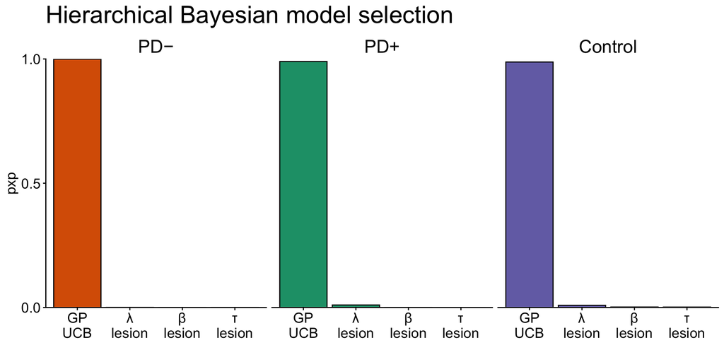

Figure 7: Hierarchical Bayesian model selection, where pxp defines the probability of each model being the most frequent in the population

```r
# load data with pxp values (pre computed via Python code in github repo)
df_pxp <- read_csv("modelResults/pxp.csv")

df_pxp_long <-
  df_pxp %>%
  pivot_longer(cols=-condition, values_to = "pxp", names_to = "model") %>%
  mutate(
    model = factor(model,
                   levels = c("RBF_UCB", "BMT_UCB", "RBF_GM", "RBF_epsilonGreedy")),
    model = fct_recode(model,
                       "GP\nUCB" = "RBF_UCB",
                       "lambda\nlesion" = "BMT_UCB",
                       "beta\nlesion"  = "RBF_GM",
                       "tau\nlesion" = "RBF_epsilonGreedy")
  ) %>%
  mutate(
    condition = factor(condition,
                       levels = c("PD-", "PD+", "control")),
    condition = fct_recode(condition, "Control" = "control"))

# grouped by model
p_pxp <-
  ggplot(df_pxp_long, aes(x = condition, y = pxp, fill = condition)) +
  facet_wrap(
    ~ model,
    nrow = 1,
    labeller = as_labeller(
      c(
        "GP\nUCB"    = "GP-UCB",
        "lambda\nlesion" = "lambda~' lesion'",
        "beta\nlesion"   = "beta~' lesion'",
        "tau\nlesion"    = "tau~' lesion'"
      ),
      label_parsed
    )
  ) +
  geom_bar(stat= "identity", color = "black") +
  scale_y_continuous(name = "pxp", breaks = c(0, 0.5, 1), limits = c(0,1), expand = c(0,0))+
  scale_x_discrete("") +
  scale_fill_manual(values = groupcolors) +
  ggtitle("Hierarchical Bayesian model selection") +
  theme_classic() +
  theme(strip.background = element_blank(),
        strip.text = element_text(color = "black", size=18),
        legend.position = "none",
        legend.justification = c(0, 1),
        axis.title = element_text(size = 14),
        axis.text = element_text(size = 14),
        plot.title = element_text(size = 24)
  )

# grouped by patient group
p_pxp <-
  ggplot(df_pxp_long, aes(x = model, y = pxp, fill = condition)) +
  facet_wrap(
    ~condition,
    nrow = 1,
    labeller = as_labeller(c(
      "Control" = "Control",
      "PD+"     = "PD+",
      "PD-"     = "PD\u2212" # unicode minus
    ))
  ) +
  geom_bar(stat= "identity", color = "black") +
  scale_y_continuous(
    name = "pxp",
    breaks = c(0, 0.5, 1),
    limits = c(0, 1),
    expand = c(0, 0)
  ) +
  scale_x_discrete("",
                   labels = c(
                     "lambda\nlesion" = "λ\nlesion",
                     "beta\nlesion"   = "β\nlesion",
                     "tau\nlesion"    = "τ\nlesion"
                   )) +
  # ggthemes::scale_fill_tableau(name = NULL) +
  scale_fill_manual(values = groupcolors) +
  ggtitle("Hierarchical Bayesian model selection") +
  theme_classic() +
  theme(strip.background = element_blank(),
        strip.text = element_text(color = "black", size=18),
        legend.position = "none",
        legend.justification = c(0, 1),
        axis.title = element_text(size = 14),
        axis.text = element_text(size = 14),
        plot.title = element_text(size = 24)
  )

p_pxp

# ggsave("plots/p_model_comparison_pxp.png", p_pxp, height = 4, width=8)
```

Models’ predictive accuracy was assessed using a pseudo-$R^2$ measure, based on the sum of negative log-likelihoods across all out-of-sample predictions. The summed log loss is compared to a random model, such that $R^2=0$ corresponds to chance performance and $R^2=1$ corresponds to theoretically perfect predictions.

$$R^2 = 1 - \frac{\log \mathcal{L}(M_k)}{\log\mathcal{L}(M_{rand})},$$
In each group, the GP-UCB model had the highest predictive accuracy (Section 7).

#### 5.6.2.2 Model-based classification of participants

```r
# get subject information
groupDF <-dat_sample %>%
  select(id, age, gender,group,BDI,MMSE,hoehn_yahr,last_ldopa,next_ldopa,time_exp,time_since_ldopa) %>%#
  group_by(id) %>%
  slice_head(n = 1) %>%
  arrange(group)

# groupDF <- dat %>%
#   group_by(id) %>%
#   slice(1) %>%
#   ungroup()

# length(unique(dat$id))
# length(unique(groupDF$id))

modelFits <- merge(modelFits, groupDF[,c('id', 'group')], by = "id") # merge to add group
#length(unique(modelFits$id))

# write individual model fits by group
# write_csv(modelFits, "modelResults/modelFits_group.csv")
# write_csv(subset(modelFits, group == "Control"), "modelResults/modelFits_control.csv")
# write_csv(subset(modelFits, group == "PD-"),"modelResults/modelFits_PD_minus.csv")
# write_csv(subset(modelFits, group == "PD+"), "modelResults/modelFits_PD_plus.csv")

# kernels <- c("RBF", "BMT") # RBF = Radial Basis Function kernel, BMT= Bayesian Mean Tracker
# acqFuncs <- c("GM", "UCB", "EG") # UCB = Upper Confidence Bound, GM=greedyMean, EG = epsilonGreedy
modelFits <-  modelFits %>%
  mutate(kernel=factor(kernel, levels=c('RBF', 'BMT'), labels=c('GP', 'BMT'))) %>%
  mutate(acq=factor(acq, levels=c('UCB', 'GM','epsilonGreedy'), labels=c('UCB', 'meanGreedy', 'epsilonGreedy')))

modelFits$ModelName = paste(modelFits$kernel, modelFits$acq, sep="-")

# Only include key comparisons
modelFits <- subset(modelFits, ModelName %in% c("GP-UCB", "BMT-UCB", "GP-meanGreedy", "GP-epsilonGreedy" ))
modelFits$ModelName = factor(modelFits$ModelName, levels = c('GP-UCB', 'BMT-UCB', 'GP-meanGreedy', 'GP-epsilonGreedy'))

#Two line name for models
modelFits$shortname <- factor(modelFits$ModelName, labels = c('GP\nUCB', 'lambda\nlesion', 'beta\nlesion', 'tau\nlesion'))
levels(modelFits$shortname) <- c('GP\nUCB', 'lambda\nlesion', 'beta\nlesion', 'tau\nlesion')
```

```r
# classify participants according to model R^2
df_participant_classification <- modelFits %>%
  group_by(id) %>%
  slice_max(order_by = R2, n = 1) %>%
  select(id, group, ModelName, shortname, R2) %>%
  ungroup() %>%
  rename(best_ModelName = ModelName,
         best_shortname = shortname,
         best_R2 = R2)

df_counts <- df_participant_classification %>%
  count(group, best_shortname)

df_percent <- df_counts %>%
  group_by(group) %>%
  mutate(
    total_in_group = sum(n),
    percent = round((n / total_in_group) * 100, 1)
  ) %>%
  ungroup()

# add most predictive model for each subject to df modelFits
modelFits <- modelFits %>%
  left_join(df_participant_classification, by = c("id", "group"))
```

We classified participants based on which model achieved the highest cross-validated predictive accuracy (highest $R^2$ or, equivalently, lowest log loss). In each patient group, the GP-UCB model was the most predictive model for the majority of participants (Control: 57.1%, PD+: 55.9%, PD-: 61.8%) (Figure 8).

In total, out of 103 participants, 60 (58.3%) were best described by the GP-UCB model, 23 (22.3%) by the lambda lesion model, 13 (12.6%) by the beta lesion model, and 7 (6.8%) by the tau lesion model. The results suggest that all three components of the GP-UCB model are relevant for predicting participants’ behavior.

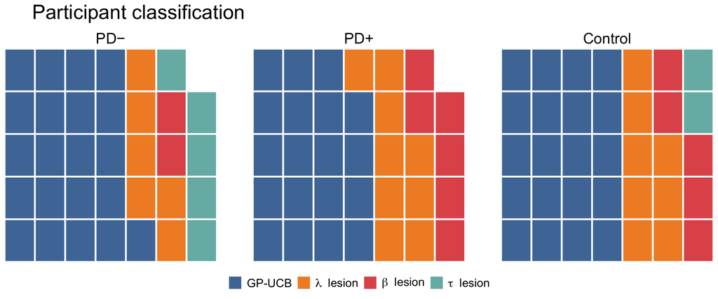

Figure 8: Classification of participants by models’ cross-validated predictive accuracy. Each square is one participant, coloured according to the model that best predicted their perfomance (=highest R2).

```r
# waffle plot
p_classification_participants <-
  ggplot(
    data = df_counts,
    aes(fill=best_shortname, values=n)
  ) +
  geom_waffle(
    color = "white",
    size = 1,
    n_rows = 5
  ) +
  facet_wrap(
    ~group,
    nrow = 1,
    labeller = as_labeller(c(
      "Control" = "Control",
      "PD+"     = "PD+",
      "PD-"     = "PD\u2212" # unicode minus
    ))
  ) +
  scale_x_discrete(
    expand = c(0,0,0,0)
  ) +
  scale_y_discrete(
    expand = c(0,0,0,0)
  ) +
  # ggthemes::scale_fill_tableau(name=NULL) +
  ggthemes::scale_fill_tableau(
    name = NULL,
    labels = c(
      "GP\nUCB"    = "GP-UCB",
      "lambda\nlesion" = expression(lambda ~ " lesion"),
      "beta\nlesion"   = expression(beta ~ " lesion"),
      "tau\nlesion"    = expression(tau ~ " lesion")
    )
  ) +
  # coord_equal() +
  ggtitle ("     Participant classification") +
  theme_classic() +
  theme(
    legend.title = element_blank(),
    plot.title = element_text(size = 24),
    legend.position = 'bottom',
    strip.text = element_text(color = "black", size=18),
    legend.text =  element_text(colour="black", size=14),
    text = element_text(colour = "black"),
    strip.background =element_blank(),
    axis.text= element_text(colour="black", size = 18),
    panel.grid.major = element_blank(),
    panel.grid.minor = element_blank(),
    panel.spacing = unit(3, "lines"),
    legend.key.spacing.y = unit(0.4, "cm")
    # plot.margin = margin(-70, 0, -30, 0) # negativ bottom margin, otherwise artfecat when putting later together with cowplot
  )

p_classification_participants
# ggsave("plots/participant_classification.png", p_classification_participants, width = 12, height = 5, dpi=300)
```

### 5.6.3 Analysis of parameter estimates: Levodopa selectively alters uncertainty-directed but not random exploration in PD

The parameters of the GP-UCB model provide a computational perspective onto distinct aspects of learning and exploration. The parameter $\lambda$ of the learning model captures how strongly a learner generalizes, the uncertainty bonus $\beta$ tracks the level of uncertainty-directed exploration, and the temperature parameter $\tau$ indicates the amount of random exploration.

```r
df_gpucb_params <- modelFits %>% filter(kernel=='GP' & acq == 'UCB') %>%
  pivot_longer(c('lambda', 'beta', 'tau'), names_to = 'param', values_to = 'estimate') %>%
  mutate(param = factor(param, levels = c('lambda', 'beta', 'tau'))) %>%
  mutate(estimate_log10 = log10(estimate))


df_gpucb_params %>%
  group_by(group, param) %>%
  summarise(
    mean = mean(estimate, na.rm = TRUE),
    median = median(estimate, na.rm = TRUE),
    se = sd(estimate, na.rm = TRUE) / sqrt(n()),
    ci_lower = mean - 1.96 * se,
    ci_upper = mean + 1.96 * se,
    .groups = "drop"
  ) %>%
  mutate(
    summary = sprintf("M = %.2f [%.2f, %.2f], Mdn = %.2f", mean, ci_lower, ci_upper, median)
  ) %>%
  select(group, param, summary) %>%
  pivot_wider(names_from = param, values_from = summary) %>%
  kable(format = "html") %>%
  kable_styling("striped", full_width = FALSE)
```

Table 5: Mean (95% CI) and median parameter estimates of the GP-UCB model by group.

| group | lambda | beta | tau |
| --- | --- | --- | --- |
| PD- | M = 0.53 [0.45, 0.61], Mdn = 0.46 | M = 9.57 [3.64, 15.49], Mdn = 0.54 | M = 1.29 [0.24, 2.35], Mdn = 0.06 |
| PD+ | M = 0.55 [0.50, 0.61], Mdn = 0.52 | M = 2.13 [-0.03, 4.29], Mdn = 0.37 | M = 0.40 [-0.10, 0.91], Mdn = 0.04 |
| Control | M = 0.64 [0.57, 0.72], Mdn = 0.58 | M = 2.30 [-0.61, 5.21], Mdn = 0.37 | M = 0.63 [-0.39, 1.66], Mdn = 0.03 |

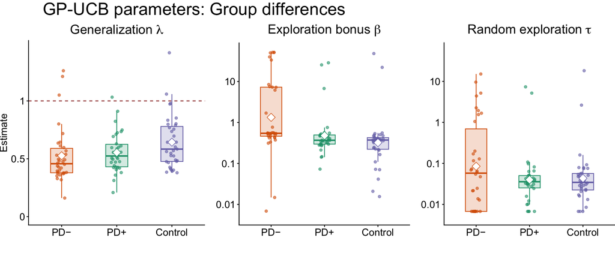

Figure 9: Parameter estimates of GP-UCB model, estimated through leave-one-round-out cross validation. Each dot is one participant.

```r
# separate plots
# generalization lambda
p_gpucb_params_lambda <-
  ggplot(subset(df_gpucb_params, param == "lambda"), aes(x = group, y = estimate, fill = group, color = group)) +
  geom_hline(yintercept = 1, linetype = "dashed", color = "darkred") + # true lambda
  scale_y_continuous(name = "Estimate", breaks = c(0, 0.5, 1, 2), labels = c("0", "0.5", "1", "2"), limits = c(0, 1.45)) +
  geom_boxplot(alpha = 0.2, width = 0.4, outlier.shape = NA) +
  geom_jitter(width = 0.1, size = 1.5, alpha = 0.6) +
  stat_summary(fun = mean, geom = "point", shape = 23, fill = "white", size = 4) +
  scale_color_manual(values = groupcolors, labels = grouplabels) +
  scale_fill_manual(values = groupcolors, labels = grouplabels) +
  scale_x_discrete("", labels = grouplabels) +
  # ggtitle("GP-UCB parameter estimates: Group differences") +
  ggtitle(expression("Generalization " * lambda)) +
  theme_classic() +
  theme(legend.position = "none",
        legend.justification = c(0, 1),
        axis.title = element_text(size = 14),
        axis.text = element_text(size = 14),
        plot.title = element_text(size = 18, hjust = 0.5),
        plot.margin = margin(10, 0, 10, 0)
  )

# p_gpucb_params_lambda
# ggsave("plots/GP-p_gpucb_params_lambda.png", p_gpucb_params_lambda, dpi=300, width = 4, height = 4)

# exploration bonus beta
p_gpucb_params_beta <-
  ggplot(subset(df_gpucb_params, param == "beta"), aes(x = group, y = estimate, fill = group,  color = group)) +
  scale_y_log10(name = " ", breaks = c(0.01, 0.1, 1, 10), labels = c("0.01", "0.1", "1", "10"), limits = c(0.005, 55)) +
  geom_boxplot(alpha = 0.2, width = 0.4, outlier.shape = NA) +
  geom_jitter(width = 0.1, size = 1.5, alpha = 0.6) +
  stat_summary(fun = mean, geom = "point", shape = 23, fill = "white", size = 4) +
  scale_color_manual(values = groupcolors, labels = grouplabels) +
  scale_fill_manual(values = groupcolors, labels = grouplabels) +
  scale_x_discrete("", labels = grouplabels) +
  # ggtitle("GP-UCB parameter estimates: Group differences") +
  ggtitle(expression("Exploration bonus " * beta)) +
  theme_classic() +
  theme(legend.position = "none",
        legend.justification = c(0, 1),
        axis.title = element_text(size = 14),
        axis.text = element_text(size = 14),
        plot.title = element_text(size = 18, hjust = 0.5),
        plot.margin = margin(10, 0, 10, 0)
  )

# p_gpucb_params_beta
# ggsave("plots/GP-p_gpucb_params_beta.png", p_gpucb_params_beta, dpi=300, width = 4, height = 4)

# random exploration temperature tau
p_gpucb_params_tau <-
  ggplot(subset(df_gpucb_params, param == "tau"), aes(x = group, y = estimate, fill = group, color = group)) +
  scale_y_log10(name = " ", breaks = c(0.01, 0.1, 1, 10), labels = c("0.01", "0.1", "1", "10"), limits = c(0.005, 55)) +
  geom_boxplot(alpha = 0.2, width = 0.4, outlier.shape = NA) +
  geom_jitter(width = 0.1, size = 1.5, alpha = 0.6) +
  stat_summary(fun = mean, geom = "point", shape = 23, fill = "white", size = 4) +
  scale_color_manual(values = groupcolors, labels = grouplabels) +
  scale_fill_manual(values = groupcolors, labels = grouplabels) +
  scale_x_discrete("", labels = grouplabels) +
  # ggtitle("GP-UCB parameter estimates: Group differences") +
  ggtitle(expression("Random exploration " * tau)) +
  theme_classic() +
  theme(legend.position = "none",
        legend.justification = c(0, 1),
        axis.title = element_text(size = 14),
        axis.text = element_text(size = 14),
        plot.title = element_text(size = 18, hjust = 0.5),
        plot.margin = margin(10, 0, 10, 0)
  )

# p_gpucb_params_tau
# ggsave("plots/GP-p_gpucb_params_tau.png", p_gpucb_params_tau, dpi=300, width = 4, height = 4)

# put together and add title
p_gpucb_params <- grid.arrange(
  grobs = list(p_gpucb_params_lambda, p_gpucb_params_beta, p_gpucb_params_tau),
  nrow = 1,
  top = textGrob(
    "         GP-UCB parameters: Group differences",
    x = 0,
    hjust = 0,
    gp = gpar(fontsize = 24)
  ),
  padding = unit(0.5, "lines")
)

# ggsave("plots/gpucb_params.png", p_gpucb_params, dpi = 300, width = 12, height = 4)
```

To better understand the mechanisms underlying the observed behavioral differences, we analyzed the parameters of the Gaussian Process Upper Confidence Bound (GP-UCB) model (Figure 9).

#### 5.6.3.1 Generalization $\lambda$

- Control vs. PD+: $U=720$, $p=.136$, $r_{ au}=.15$, $BF=.74$
- Control vs. PD-: $U=832$, $p=.004$, $r_{ au}=.28$, $BF=5.8$
- PD+ vs. PD-: $U=706$, $p=.118$, $r_{ au}=.16$, $BF=.47$

#### 5.6.3.2 Exploration bonus $\beta$

The parameter $\beta$ represents the uncertainty bonus, i.e. how much expected rewards are positively inflated by their uncertainty (higher $\beta$ = more uncertainty-directed exploration). Controls and PD+ patients on medication did not differ, and both groups had lower beta estimates than the dopamine-depleted patients in the PD− group. These differences suggest that levodopa medication modulated the amount of uncertainty-directed exploration by restoring beta to levels comparable to those observed in controls without PD. This aligns with findings from a restless bandit paradigm, where L-Dopa reduced the amount of directed exploration in healthy volunteers, while the level of random exploration remained unaffected (Chakroun et al., 2020).

- Control vs. PD+: $U=506$, $p=.290$, $r_{ au}=-.11$, $BF=.49$
- Control vs. PD-: $U=224$, $p<.001$, $r_{ au}=-.44$, $BF>100$
- PD+ vs. PD-: $U=271$, $p<.001$, $r_{ au}=-.38$, $BF=17$

#### 5.6.3.3 Random exploration $\tau$

- Control vs. PD+: $U=609$, $p=.872$, $r_{ au}=.02$, $BF=.25$
- Control vs. PD-: $U=553$, $p=.621$, $r_{ au}=-.05$, $BF=.27$
- PD+ vs. PD-: $U=517$, $p=.461$, $r_{ au}=-.08$, $BF=.28$

#### 5.6.3.4 Model simulations

To evaluate how well different parameter settings balance exploration and exploitation, we conducted simulations with the GP-UCB model. In these simulations, we fixed the value of $\lambda$ to 1, corresponding to the true amount of correlation in the used environments (length-scale of the RBF kernel), and systematically varied the amount of random exploration ($\tau$) and the size of the uncertainty bonus ($\beta$). For each parameter we defined used equally log-spaced values, and then simulated 1000 learners searching for rewards. Environments were sampled (with replacement) from the set of 40 environments used in the empirical study.

Figure 10 depicts the resulting performance landscape together with the inferred parameters of all participants (Table 5). Compared to PD$-$ patients off medication, the parameter estimates for PD$+$ patients on medication and controls cluster more closely around the optimal region. Particularly the inflated exploration bonus $\beta$ places PD$-$ patients in regions yielding low performance.

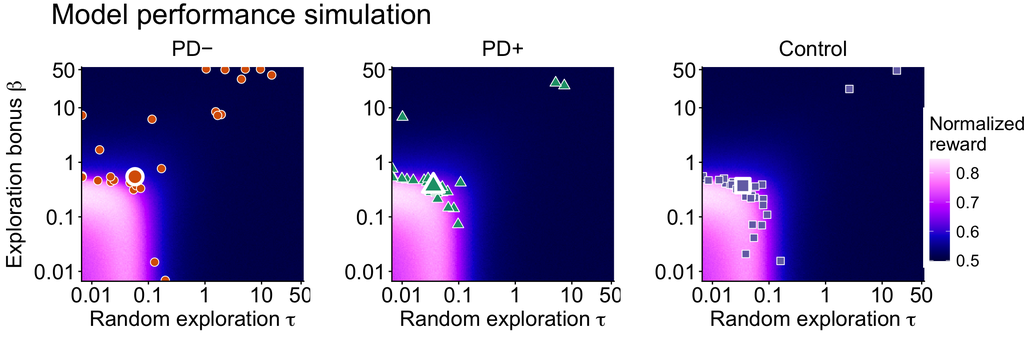

```r
# simulation results (pre-computed) using modelResults.R
# due to the file size limit on github we only store the mean values whcih are then plotted
# files with full simulation data:
# sim  <-  read.csv('modelResults/simulatedModels_local_lambda_1_0.csv') # large (>2TB) csv file
# saveRDS(sim, 'modelResults/simulatedModels_local_lambda_1_0.rds')
# sim <- readRDS('modelResults/simulatedModels_local_lambda_1_0.rds')

# normalize reward
# sim$meanReward = sim$mu / 50
#
# sim_means <-  sim %>%
#   group_by(tau,beta) %>%
#   summarise(meanReward = mean(mu)) %>%
#   mutate(meanReward = meanReward/50) %>%
#   mutate(beta_log10 = log10(beta),
#          tau_log10 = log10(tau)
#   )

# write.csv(sim_means, 'modelResults/simulatedModels_means_lambda_1_0.csv')

#get data, already averaged across the 1000 simulations per paramater combination
sim_means  <-  read.csv('modelResults/simulatedModels_means_lambda_1_0.csv')

# get parameter estimates by group
marker <- df_gpucb_params %>%
  group_by(group, param) %>%
  summarise(#mean = mean(estimate, na.rm = TRUE),
    median = median(estimate, na.rm = TRUE),
    .groups = "drop") %>%
  filter(param %in% c("beta", "tau")) %>%
  pivot_wider(names_from = param, values_from = median) %>%
  mutate(beta_log10 = log10(beta), tau_log10 = log10(tau))

# get median parameter estimates by group
marker2 <-
  df_gpucb_params %>%
  select(id, group, param, estimate) %>%
  filter(param %in% c("beta", "tau")) %>%
  pivot_wider(names_from = param, values_from = estimate) %>%
  mutate(beta_log10 = log10(beta), tau_log10 = log10(tau))


# tick positions in the original scale
#lower_bound <- exp(-5)  # ~0.0067
#upper_bound <- exp(4)   # ~54.598

bx <- c(0.001, 0.01, 0.1, 1, 10, 50) # exploration bonus beta
by <- c(0.001, 0.01, 0.1, 1, 10, 50) # temperature tau

# Control group
p_model_simulation_params_control <-
  ggplot(sim_means, aes(y = beta_log10, x = tau_log10, fill = meanReward)) +
  geom_raster() +
  scale_x_continuous(expression(paste('Random exploration ', tau)), breaks = log10(bx), labels = bx, expand = c(0,0)) +
  scale_y_continuous( expression(paste('Exploration bonus ', beta)), breaks = log10(by), labels = by, expand = c(0,0)) +
  # labs(y = expression(paste('Exploration bonus ', beta)),
  #      x = expression(paste('Random exploration ', tau))) +
  scale_fill_gradientn(colours = cet_pal(5, name = "l7"), name = "Normalized\nreward") + #l3 l6 l16 i5 "rainbow"
  geom_jitter( # add individual points
    data = subset(marker2, group == "Control"),
    aes(y = beta_log10, x = tau_log10, shape = group, colour = group),
    inherit.aes = FALSE,
    size = 3,
    fill = "#7570b3",
    shape = 22,
    stroke = 0.5,
    color = "white",
    width = 0
  ) +
  geom_point( # add median
    data = subset(marker, group == "Control"),
    aes(y = beta_log10, x = tau_log10, colour = group),
    inherit.aes = FALSE,
    shape = 22,
    size = 5,
    stroke = 2,
    fill = "#7570b3",
    color = "white"
  ) +
  ggtitle("Control") +
  theme_classic() +
  theme(strip.background = element_blank(),
        strip.text = element_text(color = "black", size=18),
        legend.position = "none",
        axis.title = element_text(size = 18),
        axis.text = element_text(size = 18),
        plot.title = element_text(size = 18, hjust = 0.5),
        axis.title.y = element_blank()
  )

#p_model_simulation_params_control

# PD- group
p_model_simulation_params_pd_off <-
  ggplot(sim_means, aes(y = beta_log10, x = tau_log10, fill = meanReward)) +
  geom_raster() +
  scale_x_continuous(expression(paste('Random exploration ', tau)), breaks = log10(bx), labels = bx, expand = c(0,0)) +
  scale_y_continuous( expression(paste('Exploration bonus ', beta)), breaks = log10(by), labels = by, expand = c(0,0)) +
  scale_fill_gradientn(colours = cet_pal(5, name = "l7"), name = "Normalized\nreward") + #l3 l16 i5 "rainbow"
  geom_jitter( # add individual points
    data = subset(marker2, group == "PD-"),
    aes(y = beta_log10, x = tau_log10, shape = group, colour = group),
    inherit.aes = FALSE,
    size = 3,
    color = "white",
    fill = "#d95f02",
    shape = 21,
    stroke = 0.5,
    width = 0
  ) +
  geom_point( # add median
    data = subset(marker, group == "PD-"),
    aes(y = beta_log10, x = tau_log10, colour = group),
    inherit.aes = FALSE,
    shape = 21,
    size = 5,
    stroke = 2,
    fill = "#d95f02",
    color = "white"
  ) +
  ggtitle("PD\u2212") +
  theme_classic() +
  theme(strip.background = element_blank(),
        strip.text = element_text(color = "black", size=18),
        legend.position = "none",
        axis.title = element_text(size = 18),
        axis.text = element_text(size = 18),
        plot.title = element_text(size = 18, hjust = 0.5)
  )

# PD+ group
p_model_simulation_params_pd_on <-
  ggplot(sim_means, aes(y = beta_log10, x = tau_log10, fill = meanReward)) +
  geom_raster() +
  scale_x_continuous(expression(paste('Random exploration ', tau)), breaks = log10(bx), labels = bx, expand = c(0,0)) +
  scale_y_continuous( expression(paste('Exploration bonus ', beta)), breaks = log10(by), labels = by, expand = c(0,0)) +
  scale_fill_gradientn(colours = cet_pal(5, name = "l7"), name = "Normalized\nreward") + #l3 l16 i5 "rainbow"
  geom_jitter( # add individual points
    data = subset(marker2, group == "PD+"),
    aes(y = beta_log10, x = tau_log10, shape = group, colour = group),
    inherit.aes = FALSE,
    size = 3,
    color = "white",
    fill = "#1b9e77",
    shape = 24,
    stroke = 0.5,
    width = 0
  ) +
  geom_point( # add median
    data = subset(marker, group == "PD+"),
    aes(y = beta_log10, x = tau_log10, colour = group),
    inherit.aes = FALSE,
    shape = 24,
    size = 5,
    stroke = 2,
    fill = "#1b9e77",
    color = "white"
  ) +
  ggtitle("PD+") +
  theme_classic() +
  theme(strip.background = element_blank(),
        strip.text = element_text(color = "black", size=18),
        legend.position = "none",
        axis.title = element_text(size = 18),
        axis.text = element_text(size = 18),
        plot.title = element_text(size = 18, hjust = 0.5),
        axis.title.y = element_blank()
  )
# p_model_simulation_params_pd_on

# Extract legend
shared_legend <- cowplot::get_legend(
  p_model_simulation_params_control +
    theme(legend.position = "right",
          legend.title = element_text(size = 16),
          legend.text  = element_text(size = 14))
)

# combine plots
p_model_simulation_params_combined <- cowplot::plot_grid(
  p_model_simulation_params_pd_off,
  p_model_simulation_params_pd_on,
  p_model_simulation_params_control,
  nrow = 1, align = "hv", axis = "tblr", rel_widths = c(1,1,1),
  labels = NULL
)

# add  legend
p_model_simulation_params_combined <- cowplot::plot_grid(
  p_model_simulation_params_combined, shared_legend,
  ncol = 2, rel_widths = c(1, 0.10)
)

# add title
p_model_simulation_params <- ggdraw() +
  draw_label(
    "Model performance simulation",
    x = 0.05, y = 0.99,
    hjust = 0,
    vjust = 1,
    size = 24
  ) +
  draw_plot(p_model_simulation_params_combined, y = 0, height = 0.9)

p_model_simulation_params
# ggsave("plots/model_simulation_params.png", p_model_simulation_params, width = 14, height = 5, dpi = 300)
```

# 6 Article figures

## 6.1 Figure 1. Task and computational model

The following code generates Figure 1 from the article by combining the individual plots generated above.

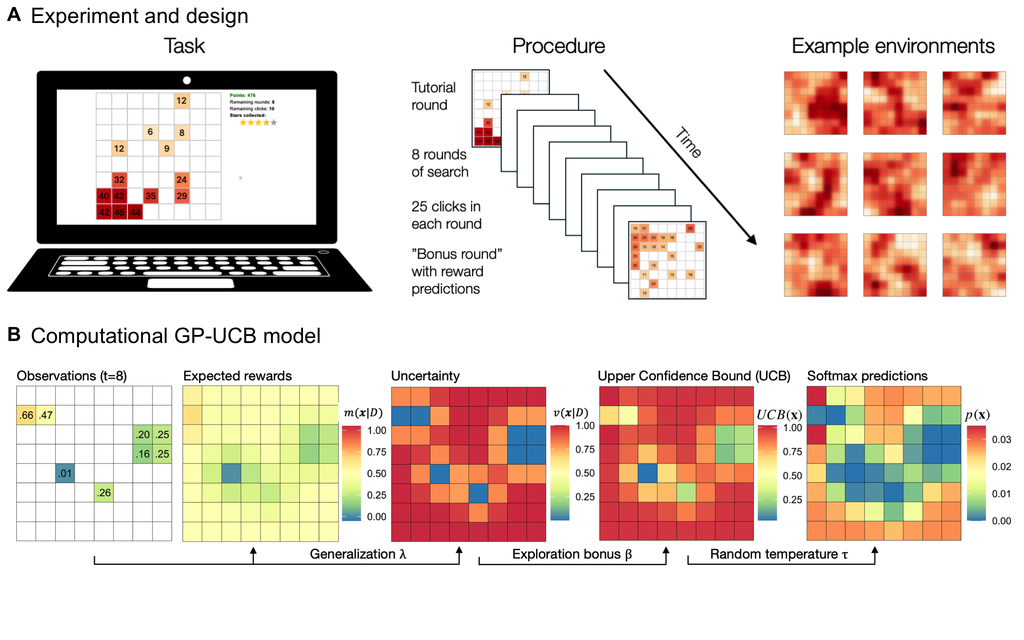

Figure 11: Task and computational model

```r
# get task illustration
img_task <- image_read("img/task.png")
gimg_task <- rasterGrob(as.raster(img_task), interpolate = TRUE)

# add title
task <- ggdraw() +
  draw_label("Experiment and design", size = 24, x = 0.03, y = 1, hjust = 0, vjust = 1.5) +
  draw_grob(gimg_task, y = -0.02)

# get GP-UCB model illustration
img_model <- image_read("img/GP-UCB model.png")
gimg_model <- rasterGrob(as.raster(img_model), interpolate = TRUE)

# add title
model <- ggdraw() +
  draw_label("Computational GP-UCB model", size = 24, x = 0.03, y = 1, hjust = 0, vjust = 1.5) +
  draw_grob(gimg_model, y = 0.05)

cowplot::plot_grid(
  task,
  model,
  ncol = 1,
  labels = c("AUTO"),
  label_size = 22,
  label_y = c(1, 1),  # vertikale Position der cowplot-Labels (A, B)
  label_x = c(0, 0)   # horizontale Position (links)
)

ggsave("plots/Fig1_task_model.png", dpi=300, height=10, width=15)
# ggsave("plots/Fig1_task_model.pdf", height=10, width=15, limitsize = FALSE )
```

## 6.2 Figure 2. Behavioral results

The following code generates Figure 2 from the article by combining the individual plots generated above.

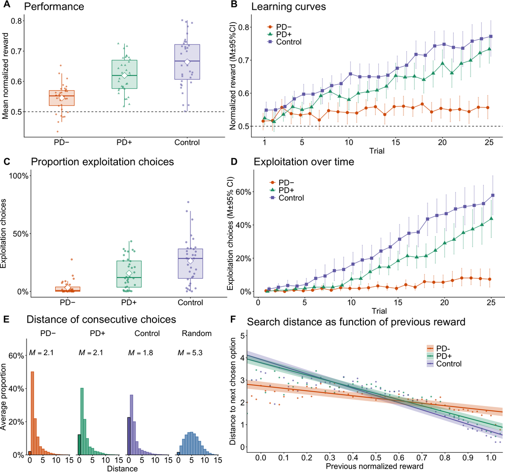

Figure 12: Behavioral results.

```r
cowplot::plot_grid(
  p_performance, p_learning_curves,
  p_explore_exploit_choices, p_explore_exploit_choices_over_time,
  p_distance_consecutive_sim, p_regression_distance_reward, #p_distance_consecutive p_types_choices_overall
  #p_bonusround_prediction_error, p_bonusround_prediction_chosen,
  labels = c("AUTO"),
  label_size = 22,
  label_y = 1.02,
  nrow = 3,
  rel_widths = c(0.45, 0.55)
)

ggsave("plots/Fig2_behavioral_results.png", dpi=300, height=15, width=18)
# ggsave("plots/Fig2_behavioral_results.pdf", height=15, width=18)
```

## 6.3 Figure 3. Computational results

The following code generates Figure 3 from the article by combining the individual plots generated above.

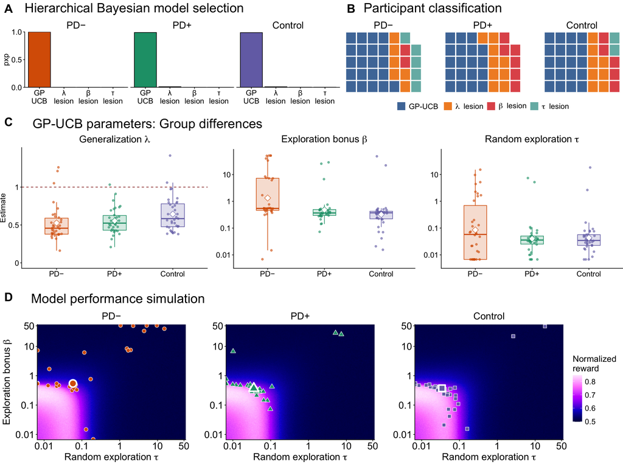

Figure 13: Computational results.

```r
# first row has model comparison: p_pxp and p_classification_participants
p_model_comparison <- plot_grid(
  p_pxp,
  p_classification_participants,
  ncol = 2,
  labels = c("A", "B"),
  label_size = 22,
  rel_widths = c(0.55,0.45)
)

# Gesamt-Layout
fig3_computational_results <- cowplot::plot_grid(
  p_model_comparison,
  p_gpucb_params,
  p_model_simulation_params,
  ncol = 1,
  # labels = "auto",
  labels = c("", "C", "D"),
  label_y = 1.02,
  # label_x = 0.1,
  label_size = 22,
  align = "h",
  axis = "l",
  rel_heights = c(2/3, 1, 1)
)

fig3_computational_results

ggsave("plots/Fig3_computational_results.png", fig3_computational_results, dpi=300, height=12, width=15)
```

# 7 Supplementary Information

## 7.1 Statistical analyses

For parametric group comparisons, we report (paired or independent) Student’s *t*-tests (two-tailed). For non-parametric comparisons we used the Mann-Whitney *U* test or Wilcoxon signed-rank test. Bayes factors for the *t*-tests were computed with the package (Morey & Rouder, 2024), using its default settings. Bayes factor for rank tests were computed following (Doorn et al., 2020).

Linear correlations were assessed using Pearson’s $r$, with the Bayes factors computed with the *BayesFactor* package (Morey & Rouder, 2024), using its default settings. Bayes factors for rank correlations quantified with Kendall’s tau were computed using an implementation from Doorn et al. (2018).

## 7.2 Supplementary behavioral results

### 7.2.1 No performance differences across rounds or clinical indicators

We conducted hierarchical Bayesian regression analyses to examine whether performance differed across task rounds or as a function of clinical indicators.

#### 7.2.1.1 No influence of rounds on performance

First, we analyzed participants’ mean reward per round as function of round number and group using a hierarchical linear regression. Group and round and their interaction were specified as population-level (fixed) effects, with group-level (random) intercepts for participants. This analysis showed only a difference between groups, but no performance differences across rounds (Table 6 and Figure 14).

```r
# mean reward per subject (practice and bonus round excluded)
df_mean_reward_subject_by_round <- dat %>%
  filter(trial != 0 & round %in% 2:9) %>% # exclude first (randomly revealed) tile and practice round and bonus round
  group_by(id, round) %>%
  summarise(age = mean(age),
            group = first(group),
            sum_reward = sum(z),
            mean_reward = mean(z),
            sd_reward = sd(z))

df_summary_by_round <- df_mean_reward_subject_by_round %>%
  group_by(round, group) %>%
  summarize(
    mean_of_means = mean(mean_reward, na.rm = TRUE),  # Renaming to avoid confusion
    se_reward = sd(mean_reward, na.rm = TRUE) / sqrt(n()),  # Standard error
    .groups = 'drop'
  )


# Plot the mean reward by round for each group with dodged points and error bars
p_rewards_round <- ggplot(df_summary_by_round, aes(x = round, y = mean_of_means, group = group, shape = group,  color = group, fill = group)) +
  geom_line(position = position_dodge(width = 0.3)) +
  # geom_errorbar(aes(ymin = mean_of_means - 1.96 * se_reward, ymax = mean_of_means + 1.96 * se_reward), width = 0.2, position = dodge, color = "black") +  #
  geom_errorbar(aes(ymin = mean_of_means - se_reward, ymax = mean_of_means + se_reward), width = 0.2, position = position_dodge(width = 0.3), alpha=0.7) +  #
  geom_point(position = position_dodge(width = 0.3), size = 3, stroke = 1, alpha=.9) +
  #coord_cartesian(ylim = c(20,40)) +
  coord_cartesian(ylim = c(0.4,0.75)) +
  #scale_shape_manual(values = c(21, 24, 22)) +  # circle, triangle, and square
  scale_fill_manual(values = groupcolors) +
  scale_color_manual(values = groupcolors) +
  #scale_color_manual(values = c("black","black","black")) +
  # scale_y_continuous("Mean reward ± 95% CI") +
  scale_y_continuous("Mean reward ± SE") +
  scale_x_continuous("Round", breaks = 2:9) +
  theme_classic() +
  theme(legend.title = element_blank(),
        plot.title = element_text(size=16),
        axis.text = element_text(size=14),
        axis.title = element_text(size=14))

# ggsave("plots/performance_rounds.png", width = 6, height = 3)
```

```r
# Hierarchical Bayesian regression analysis
# random slopes not stable
brm_rounds <- run_model(
  expr = quote(brm(
    mean_reward ~ round * group + (id | id),
    data = df_mean_reward_subject_by_round,
    family = gaussian(),
    iter = 4000,
    warmup = 1000,
    chains = 4,
    cores = 4,
    seed = 0511,
    backend = "cmdstanr",
    save_pars = save_pars(all = TRUE)
  )),
  modelName = 'brm_reward_rounds'
)

# table with key info
model_parameters(brm_rounds,
                 centrality = "mean", ci = 0.95,
                 ci_method = "hdi" ) %>%
  kable(digits = 3, format = "html")
# summary(brm_rounds)
# bayestestR:::hdi(brm_rounds, ci = 0.95) # highest density interval HDI
# tbl_regression(brm_rounds, exponentiate = F)
# posterior::summarise_draws(posterior::as_draws_array(brm_rounds))
#tab_model(brm_rounds)
#VarCorr(brm_rounds)

# Reduced model for computing BF: no round term
brm_rounds_reduced <- run_model(brm(
  mean_reward ~ group + (1 | id),
  data = df_mean_reward_subject_by_round,
  family = gaussian(),
  iter = 4000,
  warmup = 1000,
  chains = 4,
  cores = 4,
  seed = 0511,
  backend = "cmdstanr",
  save_pars = save_pars(all = TRUE)),
  modelName='brm_reward_rounds_reduced')

# estimates
# model_parameters(brm_rounds)

# Compute Bayes Factor: Full vs. Reduced (without round term)
#bf_brm_rounds <- bayes_factor(brm_rounds, brm_rounds_reduced)

# compute info from tab_model

# Fixed effects
# Posterior draws
draws <- as_draws_array(brm_rounds)

# Posterior mean and highest density interval (HDI)
fixed_df <- model_parameters(
  brm_rounds,
  effects = "fixed",
  centrality = "mean",
  ci = 0.95,
  ci_method = "hdi" # highest density interval
)

# summary info on random effects
vc <- VarCorr(brm_rounds)

# Residual variance
sigma2 <- vc$residual$sd[1, "Estimate"]^2

# variance of random intercept
tau_00 <- vc$id$sd["Intercept", "Estimate"]^2

# Compute ICC
# approximation
icc <- tau_00 / (tau_00 + sigma2)

# same as tab_model
#  performance::icc(brm_rounds) can fail with brms models, instead tab_model relies on

# format_parameters(brm_rounds)
#
# params <- model_parameters(brm_rounds) |> print_md()
```

Table 6: Hierarchical Bayesian regression results: Performance (obtained rewards) as function of group and round.

| Parameter | Component | Mean | CI | CI_low | CI_high | pd | Rhat | ESS |
| --- | --- | --- | --- | --- | --- | --- | --- | --- |
| b_Intercept | conditional | 0.532 | 0.95 | 0.494 | 0.569 | 1.000 | 1.007 | 2337.518 |
| b_round | conditional | 0.002 | 0.95 | -0.004 | 0.008 | 0.780 | 1.004 | 3498.172 |
| b_groupPDP | conditional | 0.075 | 0.95 | 0.020 | 0.127 | 0.997 | 1.003 | 3485.151 |
| b_groupControl | conditional | 0.135 | 0.95 | 0.079 | 0.184 | 1.000 | 1.014 | 495.030 |
| b_round:groupPDP | conditional | 0.000 | 0.95 | -0.008 | 0.008 | 0.504 | 1.000 | 5474.900 |
| b_round:groupControl | conditional | -0.003 | 0.95 | -0.011 | 0.005 | 0.770 | 1.013 | 452.996 |
| sigma | sigma | 0.112 | 0.95 | 0.106 | 0.117 | 1.000 | 1.006 | 2256.940 |

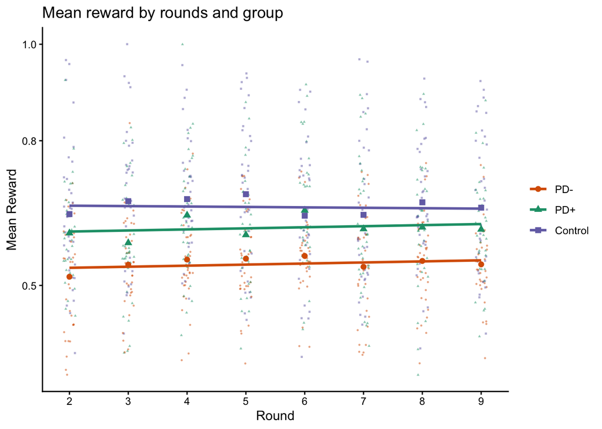

Figure 14: Reward as a function of rounds. Each line is the population-level effect of a hierarchical Bayesian regression. Large markers show the group means in each round, small dots show individual participants.

```r
# Extract fitted values and add to data df
fitted_values <- fitted(brm_rounds, re_formula = NA)
df_mean_reward_subject_by_round$fitted_mean_reward <- fitted_values[, "Estimate"]

p_rounds <-
  ggplot(df_mean_reward_subject_by_round, aes(x = round, y = mean_reward, group = group, shape = group, color = group)) +
  geom_jitter(aes(x = round, y = mean_reward), size = 0.5, alpha = 0.5, width = 0.1) +
  geom_point(data = df_summary_by_round, aes(x = round, y = mean_of_means, shape = group), size = 2) +
  geom_line(aes(y = fitted_mean_reward), linewidth = 1) +
  scale_y_continuous("Mean Reward", breaks = c(0.2,0.5,0.8,1)) +
  scale_x_continuous("Round", breaks = c(2,3,4,5,6,7,8,9)) +
  xlab("Round") +
  scale_fill_manual(values = groupcolors) +
  scale_color_manual(values = groupcolors) +
  ggtitle("Mean reward by rounds and group") +
  theme_classic() +
  theme(legend.title = element_blank())

p_rounds

ggsave("plots/S1_performance_rounds.png", p_rounds, width = 6, height = 3)
```

#### 7.2.1.2 No influence of clinical predictors on performance

Second, we assessed patients in terms of their depressive symptoms (via BDI-II), cognitive functioning (via Mini-Mental-Status Examination, MMSE), and severity of motor symptoms (via Hoehn-Yahr scale, Parkinson’s disease patients only). We ran a Bayesian hierarchical regression with reward pre trial as dependent variable and group, BDI score, and MMSE score as population-level (“fixed”) effects, and random intercepts for participants. This analysis yielded only an effect of group, suggesting that BDI and MMSE score were not related to performance (Table 7).

```r
# dat$BDI_scaled <- scale(dat$BDI)
# dat$MMSE_scaled <-  scale(dat$MMSE)

# Hierarchical Bayesian regression with random intercept: Reward as function of BDI and MMSE score (all patients)
brm_performance_BDI_MMSE <- run_model(brm(z ~ group + BDI + MMSE + (1|id),
                                          data=subset(dat, trial > 0 & round %in% 2:9 ),
                                          chains = 4,
                                          cores = 4,
                                          save_pars = save_pars(all = TRUE),
                                          seed = 0815,
                                          iter = 5000,
                                          warmup=1000,
                                          backend = "cmdstanr",
                                          control = list(adapt_delta = 0.99, max_treedepth = 15)),
                                      #prior = prior(normal(0,10), class = "b")),
                                      modelName = 'brm_performance_BDI_MMSE')

#tab_model(brm_performance_BDI_MMSE, bpe="mean")
#VarCorr(brm_performance_BDI_MMSE)
# summary(brm_performance_BDI_MMSE)
#bayes_R2(brm_performance_BDI_MMSE)

# table with key info
model_parameters(brm_performance_BDI_MMSE,
                 centrality = "mean",
                 ci = 0.95,
                 ci_method = "hdi",
                 digits = 3) %>%
  kable(digits = 3, format = "html")
```

Table 7: Hierarchical Bayesian regression with random intercept: Reward as function of BDI-II and MMSE score (all patients).

| Parameter | Component | Mean | CI | CI_low | CI_high | pd | Rhat | ESS |
| --- | --- | --- | --- | --- | --- | --- | --- | --- |
| b_Intercept | conditional | 0.111 | 0.95 | -0.369 | 0.568 | 0.684 | 1.001 | 2049.104 |
| b_groupPDP | conditional | 0.070 | 0.95 | 0.039 | 0.101 | 1.000 | 1.004 | 1911.196 |
| b_groupControl | conditional | 0.117 | 0.95 | 0.085 | 0.147 | 1.000 | 1.002 | 1602.767 |
| b_BDI | conditional | 0.000 | 0.95 | -0.003 | 0.004 | 0.540 | 1.002 | 2012.833 |
| b_MMSE | conditional | 0.015 | 0.95 | -0.001 | 0.031 | 0.969 | 1.001 | 2050.677 |
| sigma | sigma | 0.246 | 0.95 | 0.244 | 0.249 | 1.000 | 1.000 | 32483.649 |

Finally, we ran a hierarchical regression for Parkinson’s patients only, with reward as dependent variable and group, BDI, MMSE, and Hoehn-Yahr score as predictors; with random intercepts for participants to account for individual differences. This analysis only yielded an influence of group, i.e. being on or off levodopa (Table 8).

```r
# Hierarchical Bayesian regression with random intercept: Reward as function of BDI, MMSE, and Hoehner-Yahr score (Parkinson's patients only)
brm_performance_PD_only_BDI_MMSE_HY <- run_model(brm(z ~ group + BDI + MMSE + hoehn_yahr + (1|id),
                                                     data=subset(dat, trial > 0 & round %in% 2:9 & group != "Control"),
                                                     cores=4,
                                                     chains = 4,
                                                     seed = 0815,
                                                     iter = 5000,
                                                     warmup=1000,
                                                     backend = "cmdstanr",
                                                     control = list(adapt_delta = 0.99)),
                                                 #prior = prior(normal(0,10), class = "b")),
                                                 modelName = 'brm_performance_PD_only_BDI_MMSE_HY')

# tab_model(brm_performance_PD_only_BDI_MMSE_HY,  bpe="mean")
# summary(brm_performance_PD_only_BDI_MMSE_HY)
# table with key info
model_parameters(brm_performance_PD_only_BDI_MMSE_HY,
                 centrality = "mean",
                 ci = 0.95,
                 ci_method = "hdi",
                 digits = 3) %>%
  kable(digits = 3, format = "html")
```

Table 8: Hierarchical Bayesian regression: Reward as function of BDI-II, MMSE, and Hoehn-Yahr score (only PD patients).

| Parameter | Component | Mean | CI | CI_low | CI_high | pd | Rhat | ESS |
| --- | --- | --- | --- | --- | --- | --- | --- | --- |
| b_Intercept | conditional | 0.310 | 0.95 | -0.216 | 0.850 | 0.874 | 1.001 | 2836.210 |
| b_groupPDP | conditional | 0.072 | 0.95 | 0.046 | 0.097 | 1.000 | 1.001 | 2922.630 |
| b_BDI | conditional | 0.002 | 0.95 | -0.001 | 0.006 | 0.903 | 1.000 | 3475.754 |
| b_MMSE | conditional | 0.007 | 0.95 | -0.011 | 0.025 | 0.783 | 1.001 | 2832.830 |
| b_hoehn_yahr | conditional | 0.006 | 0.95 | -0.013 | 0.027 | 0.724 | 1.000 | 2583.618 |
| sigma | sigma | 0.244 | 0.95 | 0.241 | 0.246 | 1.000 | 1.000 | 24530.743 |

#### 7.2.1.3 No medication-related difference in decision latency

To examine whether the behavioral differences between PD+ and PD- patients could reflect a general slowing of responding under dopamine depletion, we conducted exploratory analyses of response time, defined as the latency between consecutive clicks on the grid. Figure 15 shows the median response time across all trials and rounds by group.

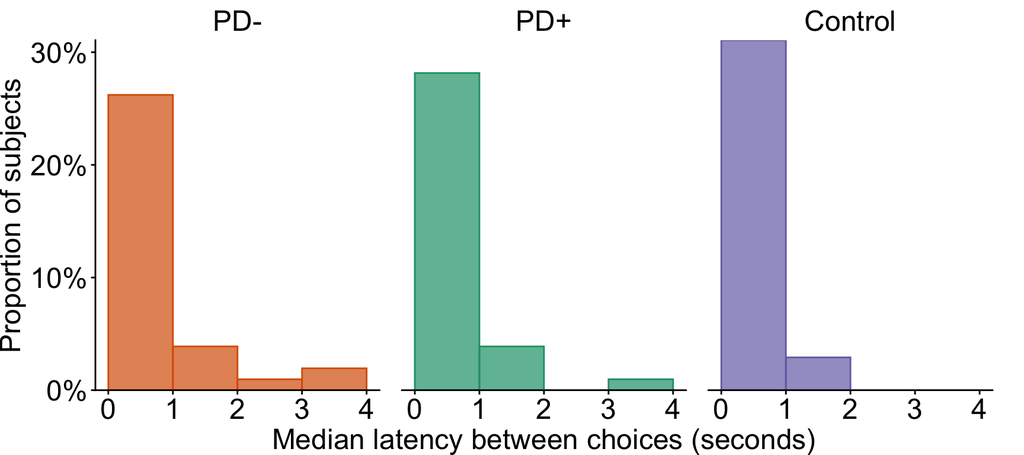

Figure 15: Median response time between consecutive clicks across all trials and rounds.

```r
# compute latency per subject, pooling all decisions across rounds 2-9
df_latency_subject <- dat %>%
  filter(trial > 0 & round %in% 2:9) %>%
  group_by(id, group) %>%
  summarise(decisions=n(),
            mean_latency_ms = mean(latency_ms, na.rm = TRUE),
            median_latency_ms = median(latency_ms),
            SD_latency_ms = sd(latency_ms),
            SE_latency_ms = SD_latency_ms / sqrt(decisions),
            .groups = "drop")

#  latency by  group
df_summary_latency <-
df_latency_subject %>%
  group_by(group) %>%
  summarise(
    n = n(),
    median_of_subject_medians_ms = median(median_latency_ms, na.rm = TRUE),
    mean_of_subject_medians_ms   = mean(median_latency_ms, na.rm = TRUE),
    sd_of_subject_medians_ms     = sd(median_latency_ms, na.rm = TRUE),
    se_of_subject_medians_ms     = sd_of_subject_medians_ms / sqrt(n),
    .groups = "drop"
  )


ggplot(df_latency_subject, aes(x = median_latency_ms/1000, fill = group, color = group)) +
  facet_wrap(~group, nrow = 1) +
  geom_histogram(aes(y = after_stat(count / sum(count))),
                 binwidth = 1,
                 boundary = 0,
                 alpha = 0.7) +
  scale_y_continuous("Proportion of subjects", labels = percent_format(), expand = c(0, 0)) +
  scale_x_continuous("Median latency between choices (seconds)") +
  scale_fill_manual(values = groupcolors) +
  scale_color_manual(values = groupcolors) +
  theme_classic() +
  theme(
    plot.title = element_text(size = 24),
    legend.title = element_blank(),
    legend.position = "none",
    legend.text = element_text(colour = "black"),
    text = element_text(colour = "black"),
    strip.background = element_blank(),
    strip.text = element_text(colour = "black", size = 18),
    axis.text = element_text(colour = "black", size = 18),
    axis.title = element_text(colour = "black", size = 18),
    panel.grid.major = element_blank(),
    panel.grid.minor = element_blank(),
    panel.spacing = unit(0.5, "cm"),
    plot.margin = margin(r = 20)
  )

ggsave("plots/decision_latency.png", dpi=300, width=9, height=4)
```

PD patients on and off medication did not differ in their median response time, and patients on medication did not differ from controls. The comparison between patients off medication and controls showed a weak trend toward longer latencies in the PD− group:

- PD+ vs. PD-: $t(66)=-0.6$, $p=.569$, $d=0.1$, $BF=.29$
- Control vs. PD+: $t(67)=-1.5$, $p=.149$, $d=0.4$, $BF=.61$
- Control vs. PD-: $t(67)=-1.9$, $p=.065$, $d=0.5$, $BF=1.1$

To examine decision latency at the trial level, we fit a Bayesian hierarchical regression model predicting response time from group and distance to the previously selected tile, with a random intercept for participant (Table 9). Because response times were strictly positive and right-skewed, we used a lognormal link function. As expected, longer distances between consecutive clicks on the grid were associated with longer latencies. Controls responded faster than PD- patients, but the difference between PD patients on and off medication was small and the HDI included zero. The effect of distance on response time was slightly stronger in controls than in PD- patients, but the effect was small.

Overall, these analyses suggest that medication status was not associated with a clear difference in response latency within the PD sample, and that latency variation was driven more strongly by search distance than by group.

```r
# multi-level regression
# dat <- dat %>% mutate(log_latency_ms = log(latency_ms))

# lmer_latency_reward_distance_group <- lmer(
#   log_latency_ms ~ previous_reward + distance + group + (1 | id),
#   data = filter(dat, round %in% 2:9, trial > 0)
# )
#
# summary(lmer_latency_reward_distance_group)
# tab_model(lmer_latency_reward_distance_group)
#
# emmeans(m1, pairwise ~ group, pbkrtest.limit = 20600)
#
# lmer_latency_reward_distance_group <- lmer(
#   log_latency_ms ~ distance * group + (1 | id),
#   data = filter(dat, round %in% 2:9, trial > 0)
# )
#
# summary(lmer_latency_reward_distance_group)


brm_latency_distance_group <- run_model(
  brm(
    latency_ms ~ distance * group + (1 | id),
    data = subset(dat, round %in% 2:9 & trial > 0 & !is.na(latency_ms)),
    family = lognormal(),
    cores = 4,
    chains = 4,
    seed = 815,
    iter = 5000,
    warmup = 1000,
    backend = "cmdstanr",
    control = list(adapt_delta = 0.99)
  ),
  modelName = "brm_latency_distance_group"
)
# summary(brm_latency_distance_group)
# tab_model(brm_latency_distance_group, transform="exp")
# tab_model(brm_latency_distance_group)

model_parameters(
  brm_latency_distance_group,
  centrality = "mean",
  ci = 0.95,
  ci_method = "hdi",
  digits = 3
) %>%
  kable(digits = 3, format = "html")
```

| Parameter | Component | Mean | CI | CI_low | CI_high | pd | Rhat | ESS |
| --- | --- | --- | --- | --- | --- | --- | --- | --- |
| b_Intercept | conditional | 6.546 | 0.95 | 6.409 | 6.686 | 1.000 | 1.008 | 317.398 |
| b_distance | conditional | 0.117 | 0.95 | 0.111 | 0.124 | 1.000 | 1.001 | 5950.325 |
| b_groupPDP | conditional | -0.117 | 0.95 | -0.325 | 0.083 | 0.869 | 1.003 | 309.818 |
| b_groupControl | conditional | -0.296 | 0.95 | -0.491 | -0.119 | 1.000 | 1.007 | 288.899 |
| b_distance:groupPDP | conditional | 0.006 | 0.95 | -0.003 | 0.014 | 0.907 | 1.001 | 6729.319 |
| b_distance:groupControl | conditional | 0.035 | 0.95 | 0.027 | 0.044 | 1.000 | 1.001 | 6724.609 |
| sigma | sigma | 0.474 | 0.95 | 0.470 | 0.479 | 1.000 | 1.000 | 11556.782 |

### 7.2.2 Bonus round: Reward predictions, confidence, and choices

In the bonus round, participants made 15 search decisions and then predicted the rewards for 5 randomly chosen, previously unobserved tiles. Subsequently, they chose one of the five tiles and continued the round until the search horizon of 25 clicks was met.

#### 7.2.2.1 Data structure

Data frame *dat_bonus* contains the following variables:

- `id`: participant id
- `bonus_env_number`: internal id of the bonus round environment
- `bonus_environment`: recodes `condition` as `Rough` (smoothness of reward function over grid, corresponding to RBF length-scale parameter $\lambda=1$)
- `x` and `y` are the coordinates of the random tiles on the grid for which participants were asked to provide reward estimates
- `givenValue`: participant reward judgment (scale 0-50)
- `howSecure`: participant confidence for given reward judgment (scale 0-10)
- `chosen_x` and `chosen_y` are the coordinates of the tile chose after making reward and confidence judgments for 5 random tiles
- `true_z` is the ground truth, i.e. true expected reward of a tile
- `error` is the absolute deviation between participants reward estimates (`givenValue`) and ground truth (`true_z`)
- `chosen` is whether the option was chosen or not (participants chose one of the five options after estimating their value and confidence in their reward prediction)

Table 10: Bonus round data.

| id | bonus_env_number | bonus_environment | x | y | givenValue | howSecure | chosen_x | chosen_y | true_z | chosen | error | group |
| --- | --- | --- | --- | --- | --- | --- | --- | --- | --- | --- | --- | --- |
| 1102 | 21 | Rough | 6 | 0 | 0.46 | 1 | 5 | 3 | 0.39 | not chosen | 0.07 | PD+ |
| 1102 | 21 | Rough | 1 | 5 | 0.44 | 2 | 5 | 3 | 0.22 | not chosen | 0.22 | PD+ |
| 1102 | 21 | Rough | 1 | 0 | 0.30 | 1 | 5 | 3 | 0.46 | not chosen | 0.16 | PD+ |
| 1102 | 21 | Rough | 5 | 6 | 0.30 | 2 | 5 | 3 | 0.45 | not chosen | 0.15 | PD+ |
| 1102 | 21 | Rough | 5 | 3 | 0.34 | 1 | 5 | 3 | 0.57 | chosen | 0.23 | PD+ |
| 111 | 38 | Rough | 5 | 6 | 0.40 | 5 | 7 | 3 | 0.33 | not chosen | 0.07 | Control |

#### 7.2.2.2 Judgment error

Figure 16 shows the mean absolute error between participants’ estimates and the true underlying expected reward. Compared to a random baseline, all groups performed better than chance level:

- Control: $t(34)=-15.8$, $p<.001$, $d=2.7$, $BF>100$
- PD+: $t(33)=-11.4$, $p<.001$, $d=2.0$, $BF>100$
- PD-: $t(33)=-10.4$, $p<.001$, $d=1.8$, $BF>100$

Controls had lower judgment error than PD- patients; no other group differences were observed.

- Control vs. PD-: $t(67)=-2.7$, $p=.009$, $d=0.6$, $BF=5.0$
- Control vs. PD+: $t(67)=-1.3$, $p=.196$, $d=0.3$, $BF=.51$
- PD+ vs. PD-: $t(66)=-1.2$, $p=.225$, $d=0.3$, $BF=.47$

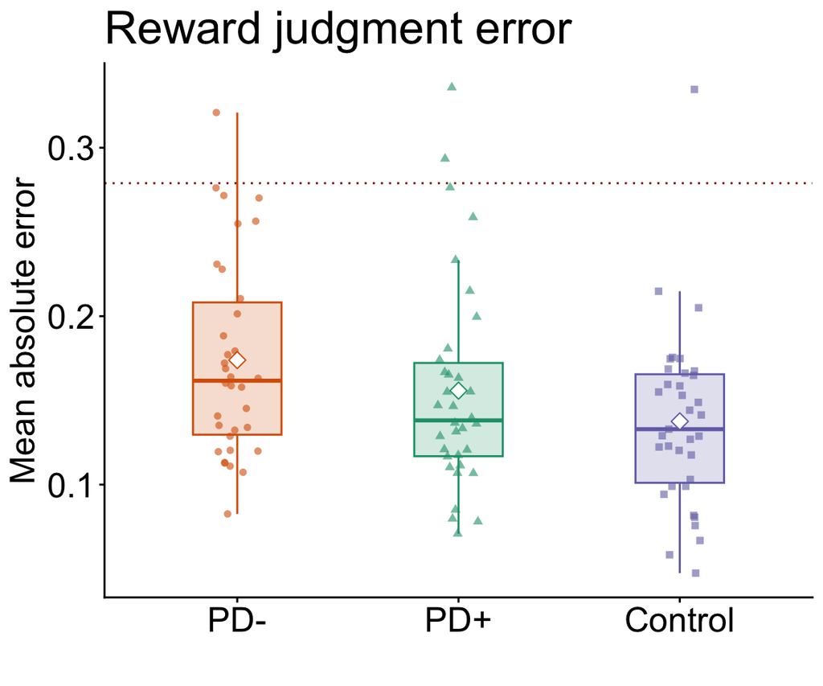

Figure 16: Judgment error of bonus round judgments. The red dotted line indicates a random baseline.

To address whether the variability in prediction error in the bonus round was related to disease severity, we ran a Bayesian linear regression in the PD sample predicting mean absolute error from medication group, BDI, MMSE, and Hoehn–Yahr score (Table 11). Posterior estimates for all predictors were small and their 95% HDIs included zero, including for Hoehn–Yahr score. Thus, we found no evidence that variability in judgment error was systematically related to disease severity or other clinical indicators.

Table 11: Bayesian regression: mean judgment error in the bonus round as a function of medication group and clinical indicators in the PD sample.

| Parameter | Component | Mean | CI | CI_low | CI_high | pd | Rhat | ESS |
| --- | --- | --- | --- | --- | --- | --- | --- | --- |
| b_Intercept | conditional | -0.058 | 0.95 | -0.675 | 0.555 | 0.574 | 1 | 11976.59 |
| b_groupPDP | conditional | -0.021 | 0.95 | -0.052 | 0.009 | 0.913 | 1 | 12827.59 |
| b_hoehn_yahr | conditional | 0.001 | 0.95 | -0.023 | 0.025 | 0.518 | 1 | 13692.70 |
| b_BDI | conditional | -0.002 | 0.95 | -0.006 | 0.002 | 0.846 | 1 | 18285.48 |
| b_MMSE | conditional | 0.009 | 0.95 | -0.011 | 0.030 | 0.799 | 1 | 12140.34 |
| sigma | sigma | 0.062 | 0.95 | 0.051 | 0.073 | 1.000 | 1 | 10668.63 |

#### 7.2.2.3 Judgment error and confidence

Aggregated across all judgments, there was no relationship between judgment error and confidence, with varying and inconsistent patterns in the different groups. The Control group showed a weak negative relation (i.e., lower confidence was associated with higher judgment error), the PD+ group a weak positive trend (i.e., lower confidence was associated with better lower judgment error), and the PD− group showed no association. None of these patterns were strong or reliable, no relationship between judgment error and confidence.

- Overall: $r=-.05$, $p=.273$, $BF=.19$
- Control: $r=-.18$, $p=.020$, $BF=2.4$
- PD+: $r=.09$, $p=.251$, $BF=.34$
- PD-: $r=-.05$, $p=.528$, $BF=.22$

```r
# bivariate relations

# Across all judgments and participants, there was no systematic relation between confidence and judgment error:
# corTestPretty(dat_bonus$error, dat_bonus$howSecure, method = "pearson")
# cor.test(dat_bonus$error, dat_bonus$howSecure, method = "pearson")
# correlationBF(dat_bonus$error, dat_bonus$howSecure, method = "pearson")
```

A Bayesian regression with judgment error as dependent variable, and confidence and group and their interaction as population-level (“fixed”) effects, and a random intercept for participants yielded the same conclusions: in control patients, confidence and judgment error were weakly negatively related (i.e., lower confidence was associated with a higher error), whereas for the two Parkinson groups confidence ratings and judgment error were not related.

```r
brm_bonus_confidence_error_by_group <- run_model(brm(error ~ howSecure * group + (1|id),
                                                     data=dat_bonus,
                                                     cores=4,
                                                     chains=4,
                                                     backend = "cmdstanr",
                                                     control = list(adapt_delta = 0.99),
                                                     iter = 5000,
                                                     warmup=1000,
                                                     seed = 0815),
                                                 modelName = 'brm_bonus_confidence_error_by_group')
#tab_model(brm_bonus_confidence_error_by_group, bpe = "mean", title = "Bayesian regression results: judgment error and confidence")

#bayes_R2(brm_bonus_confidence_error_by_group)

model_parameters(brm_bonus_confidence_error_by_group,
                 centrality = "mean",
                 ci = 0.95,
                 ci_method = "hdi",
                 digits = 3) %>%
  kable(digits = 3, format = "html")
```

| Parameter | Component | Mean | CI | CI_low | CI_high | pd | Rhat | ESS |
| --- | --- | --- | --- | --- | --- | --- | --- | --- |
| b_Intercept | conditional | 0.180 | 0.95 | 0.151 | 0.209 | 1.000 | 1 | 11809.85 |
| b_howSecure | conditional | -0.002 | 0.95 | -0.008 | 0.004 | 0.699 | 1 | 12571.20 |
| b_groupPDP | conditional | -0.039 | 0.95 | -0.085 | 0.008 | 0.947 | 1 | 12699.42 |
| b_groupControl | conditional | -0.001 | 0.95 | -0.052 | 0.048 | 0.523 | 1 | 13500.26 |
| b_howSecure:groupPDP | conditional | 0.005 | 0.95 | -0.004 | 0.014 | 0.855 | 1 | 12437.13 |
| b_howSecure:groupControl | conditional | -0.007 | 0.95 | -0.018 | 0.002 | 0.925 | 1 | 13603.41 |
| sigma | sigma | 0.115 | 0.95 | 0.107 | 0.122 | 1.000 | 1 | 10124.19 |

[figure not shown]

```r
# average not-chosen tiles within subjects first
df_chosen_overall <- dat_bonus %>%
  group_by(id, chosen) %>%
  summarise(m_givenValue = mean(givenValue),
            m_howSecure = mean(howSecure),
            m_true_z = mean(true_z))

df_chosen_group <- dat_bonus %>%
  group_by(id, group, chosen) %>%
  summarise(m_givenValue = mean(givenValue),
            m_howSecure = mean(howSecure),
            m_true_z = mean(true_z))

df_chosen_group %>%
  group_by(group,chosen) %>%
  summarise(predicted_reward = mean(m_givenValue),
            confidence = mean(m_howSecure),
            true_reward = mean(m_true_z)) %>%
  kable(format = "html", escape = F, digits = 2) %>%
  kable_styling("striped", full_width = F)
```

Chosen vs. not chosen options in bonus round: Predicted reward, true reward, and confidence in reward predictions.

| group | chosen | predicted_reward | confidence | true_reward |
| --- | --- | --- | --- | --- |
| PD- | chosen | 0.39 | 3.50 | 0.42 |
| PD- | not chosen | 0.40 | 3.60 | 0.46 |
| PD+ | chosen | 0.51 | 4.76 | 0.50 |
| PD+ | not chosen | 0.47 | 4.65 | 0.44 |
| Control | chosen | 0.49 | 4.74 | 0.45 |
| Control | not chosen | 0.43 | 4.51 | 0.44 |

```r
# make dfs for comparing predicted rewards, confidence, and true rewards

# chosen vs. not chosen tiles: predicted reward
df_chosen_group_wide_predicted_reward <- df_chosen_group  %>%
  mutate(chosen = recode(chosen,
                         "not chosen" = "not_chosen")) %>%
  select(id, chosen, m_givenValue)  %>%
  pivot_wider(names_from = chosen, values_from = m_givenValue)


# chosen vs. not chosen tiles: confidence (1-10) in rewards predictions
df_chosen_group_wide_confidence <- df_chosen_group  %>%
  mutate(chosen = recode(chosen,
                         "not chosen" = "not_chosen")) %>%
  select(id, chosen, m_howSecure)  %>%
  pivot_wider(names_from = chosen, values_from = m_howSecure)

# chosen vs. not chosen tiles: true rewards
df_chosen_group_wide_true_rewards <- df_chosen_group  %>%
  mutate(chosen = recode(chosen,
                         "not chosen" = "not_chosen")) %>%
  select(id, chosen, m_true_z)  %>%
  pivot_wider(names_from = chosen, values_from = m_true_z)
```

#### 7.2.2.4 Chosen vs. not chosen tiles: Predicted rewards

In both the control and PD+ group, selected tiles tended to have higher predicted rewards.

- Control: $t(34)=2.9$, $p=.007$, $d=0.6$, $BF=6.1$
- PD+: $t(33)=2.1$, $p=.047$, $d=0.3$, $BF=1.2$
- PD-: $t(33)=-0.2$, $p=.844$, $d=0.0$, $BF=.19$

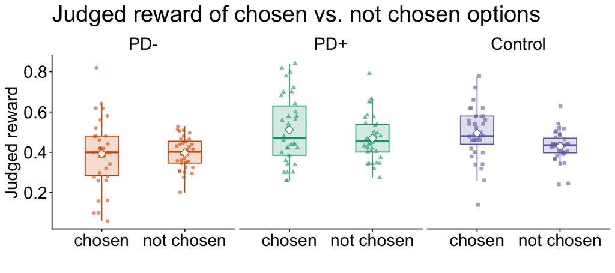

Figure 17: Judged reward of chosen vs. not chosen options in bonus round.

```r
# plot reward predictions: chosen vs not-chosen options
p_bonusround_prediction_chosen <-
  ggplot(df_chosen_group, aes(x = chosen, y = m_givenValue, color = group, fill = group, shape = group)) +
  facet_wrap(~group) +
  geom_boxplot(alpha = 0.2, outlier.shape = NA, width = 0.4) +
  geom_jitter(width = 0.1, size = 1.5, alpha = 0.6) +
  stat_summary(fun = mean, geom = "point", shape = 23, fill = "white", size = 3) +
  scale_color_manual(values = groupcolors) +
  scale_fill_manual(values = groupcolors) +
  labs(title = "Judged reward of chosen vs. not chosen options", y = "Judged reward", x = "") +
  theme_classic() +
  theme(
    legend.position = 'none',
    legend.title = element_blank(),
    plot.title = element_text(size=24),
    axis.text = element_text(size=18),
    axis.title = element_text(size=18),
    strip.background = element_blank(),
    strip.text = element_text(color = "black", size=18)
  )

p_bonusround_prediction_chosen
ggsave("plots/S4_bonusround_chosen_not_chosen_options_predicted_reward.png", p_bonusround_prediction_chosen, dpi=300, width=9, height = 4)
```

#### 7.2.2.5 Chosen vs. not chosen tiles: Confidence

There was no difference in confidence between selected and not selected tiles in any of the groups.

- Control: $t(34)=0.9$, $p=.389$, $d=0.1$, $BF=.26$
- PD+: $t(33)=0.4$, $p=.690$, $d=0.0$, $BF=.20$
- PD-: $t(33)=-0.4$, $p=.656$, $d=0.0$, $BF=.20$

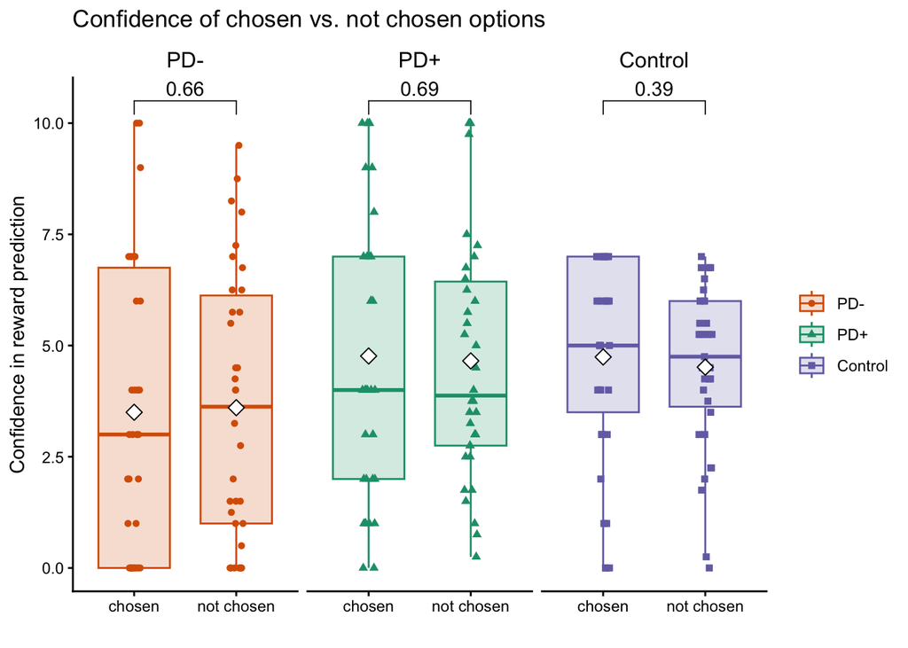

Figure 18: Confidence in reward prediction of chosen vs. not chosen options in bonus round.

```r
# chosen vs not chosen: confidence
ggboxplot(df_chosen_group, x = "chosen", y = "m_howSecure",
          color = "group", palette =groupcolors, fill = "group", alpha = 0.2,
          add = "jitter", shape = "group", title = "Confidence of chosen vs. not chosen options",
          facet.by = "group") +
  ylab("Confidence in reward prediction") +
  xlab("") +
  stat_compare_means(comparisons =  list( c("chosen", "not chosen") ), paired = T, method = "t.test", label = "p.format") +
  stat_summary(fun = mean, geom="point", shape = 23, fill = "white", size=3) +
  theme_classic() +
  theme(strip.background = element_blank(),
        strip.text = element_text(color = "black", size=12),
        legend.title = element_blank()
  )

# ggsave("plots/bonusround_chosen_not_chosen_options_confidence.png", dpi=300, width=7, height = 5)
```

## 7.3 Supplementary computational results

### 7.3.1 Model comparison

The predictive accuracy of the computational models was evaluated through leave-one-round-out cross-validation using maximum likelihood estimation (Mullen et al., 2011). Parameter bounds were set to the range $[\exp(-5), \exp(4)]$. To assess out-of-sample accuracy we iteratively removed one round from the task (test set), fitted each model to the remaining seven rounds, and then tested the model’s ability to predict participants’ choices on the 25 choices of the test set. Predictive accuracy was quantified as the sum of negative log-likelihoods across all out-of-sample predictions.

These log-likelihoods formed the basis for both the hierarchical Bayesian model selection with protected exceedance probabilities (Figure 7) and a pseudo-$R^2$ measure (Equation 14). The pseudo-$R^2$ compares each model’s log loss to that of a random baseline model, which chooses each trial with equal probability $1/64$ among all options, such that $R^2=0$ corresponds to chance performance and $R^2=1$ to theoretically perfect predictions.

The GP-UCB model outperformed all lesioned models in each group. Figure 19 provides an overview of each model’s predictive accuracy.

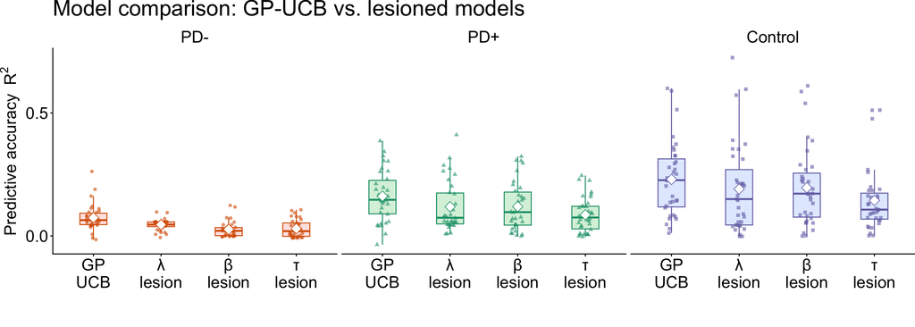

Figure 19: Predictive accuracy of GP-UCB model and lesioned variants.

```r
# perform frequentist and Bayesian t-tests and make labels for plotting
comparisons_df <- modelFits %>%
  group_by(group) %>%
  group_modify(~{
    # pariwise t-tests
    comparisons <- list(
      c("GP\nUCB", "lambda\nlesion"),
      c("GP\nUCB", "beta\nlesion"),
      c("GP\nUCB", "tau\nlesion")
    )

    t_res <- t_test(R2 ~ shortname,
                    data = .x,
                    paired = TRUE,
                    comparisons = comparisons) %>%
      add_xy_position(x = "shortname") %>%
      mutate(
        p.format = case_when(
          p < 0.001 ~ "p<.001",
          TRUE ~ paste0("p=", signif(p, 2))
        )
      )

    # compute Bayes Factors BF10
    t_res$BF <- purrr::pmap_dbl(
      list(t_res$group1, t_res$group2),
      function(g1, g2) {
        x1 <- .x$R2[.x$shortname == g1]
        x2 <- .x$R2[.x$shortname == g2]
        bf <- BayesFactor::ttestBF(x = x1, y = x2, paired = TRUE)
        as.numeric(BayesFactor::extractBF(bf)$bf)
      }
    )

    t_res
  }) %>%
  mutate( # make BF label
    BF.format = case_when(
      BF > 100 ~ "BF>100",
      TRUE ~ paste0("BF=", signif(BF, 2))
    )) %>%
  mutate(plot_label = paste0(p.format, ", ", BF.format)) # make plot label

# get y.positions from first comaprisons
ref_ypos <- comparisons_df %>%
  filter(group == first(levels(modelFits$group))) %>%
  pull(y.position)

# set manually
ref_ypos <- c(0.68, 0.74, 0.8)

comparisons_df <- comparisons_df %>%
  group_by(group) %>%
  mutate(y.position = ref_ypos) %>%
  ungroup()

p_model_comparison_R2 <- ggplot(modelFits, aes(x = shortname, y = R2, fill = group, shape = group, color = group)) +
  facet_wrap(~group, nrow = 1) +
  geom_boxplot(alpha = 0.2, width = 0.4, outlier.shape = NA) +
  geom_jitter(width = 0.1, size = 1.5, alpha = 0.6) +
  stat_summary(fun = mean, geom = "point", shape = 23, fill = "white", size = 4) +
  scale_y_continuous(name = expression("Predictive accuracy " ~ R^2),
                     breaks = c(0, 0.5, 1))+
  scale_x_discrete("",
                   labels = c(
                     "lambda\nlesion" = "λ\nlesion",
                     "beta\nlesion"   = "β\nlesion",
                     "tau\nlesion"    = "τ\nlesion"
                     # labels = c(
                     # "lambda\nlesion" = expression(atop(lambda, lesion)),
                     # "beta\nlesion"   = expression(atop(beta, lesion)),
                     # "tau\nlesion"    = expression(atop(tau, lesion))
                   )) +
  scale_color_manual(values = groupcolors) +
  ggtitle("Model comparison: GP-UCB vs. lesioned models") +
  theme_classic() +
  theme(strip.background = element_blank(),
        strip.text = element_text(color = "black", size=18),
        legend.position = "none",
        legend.justification = c(0, 1),
        axis.title = element_text(size = 18),
        axis.text = element_text(size = 18),
        plot.title = element_text(size = 24),
        plot.margin = margin(0, 0, 20, 0) # positive bottom margin, otherwise artfecat when putting later together with cowplot
  )


p_model_comparison_R2
ggsave("plots/S5_model_comparison_R2.png", p_model_comparison_R2, dpi=300, width = 10, height = 5)
#ggsave("plots/model_comparison.pdf", p_model_comparison, width = 10, height = 5) # ü

# plot for Computational Psychiatry Conference (CPP; Tübingen, July 2025)
# ggboxplot(modelFits,
#           x = "shortname",
#           y = "R2",
#           color = "group", palette = groupcolors, fill = "group", alpha = 0.2,
#           add = "jitter", jitter.size = 1, shape = "group",
#           title = "Model comparison: GP-UCB vs. lesioned models") +
#   facet_wrap(~group, nrow = 1) +
#   ylab(bquote(R^2)) +
#   xlab("") +
#   stat_pvalue_manual(
#     filter(comparisons_df, group == "Control"),
#     label = "plot_label",
#     tip.length = 0.01, bracket.size = 0.3, size = 3
#   ) +
#   stat_pvalue_manual(
#     filter(comparisons_df, group == "PD+"),
#     label = "plot_label",
#     tip.length = 0.01, bracket.size = 0.3, size = 3
#   ) +
#   stat_pvalue_manual(
#     filter(comparisons_df, group == "PD-"),
#     label = "plot_label",
#     tip.length = 0.01, bracket.size = 0.3, size = 3
#   ) +
#   theme_classic()+
#   theme(strip.background = element_blank(),
#         strip.text = element_text(color = "black", size=12),
#         legend.position = "none",
#         plot.title = element_text(size = 24),
#         axis.text= element_text(colour="black", size = 14),
#         axis.title= element_text(colour="black", size = 14)
#   )
#
# ggsave("plots/model_comparison_CPP.png", p_model_comparison_CPP, dpi=300, width = 9, height = 5)
```

We conducted pairwise comparisons (*t*-tests, two-tailed) between the GP-UCB model and the lesioned variants. Consistent with the hierarchical Bayesian model selection (Figure 7) and individual participant classification (Figure 8) according to which model best explained individual behavior (=highest $R^2$), the GP-UCB model outperformed all lesioned models in each group.

*Model comparison $R^2$: Control*

- GP-UCB vs. lambda lesion: $t(34)=3.2$, $p=.003$, $d=0.2$, $BF=12$
- GP-UCB vs. beta lesion: $t(34)=3.5$, $p=.001$, $d=0.2$, $BF=28$
- GP-UCB vs. tau lesion: $t(34)=7.9$, $p<.001$, $d=0.6$, $BF>100$

*Model comparison $R^2$: PD+*

- GP-UCB vs. lambda lesion: $t(33)=3.4$, $p=.002$, $d=0.4$, $BF=18$
- GP-UCB vs. beta lesion: $t(33)=3.8$, $p<.001$, $d=0.4$, $BF=58$
- GP-UCB vs. tau lesion: $t(33)=8.7$, $p<.001$, $d=0.9$, $BF>100$

*Model comparison $R^2$: PD-*

- GP-UCB vs. lambda lesion: $t(33)=3.8$, $p<.001$, $d=0.7$, $BF=47$
- GP-UCB vs. beta lesion: $t(33)=5.8$, $p<.001$, $d=1.1$, $BF>100$
- GP-UCB vs. tau lesion: $t(33)=5.2$, $p<.001$, $d=1.0$, $BF>100$

### 7.3.2 Simulated model performance

We additionally conducted simulations with $\lambda=0.5$, which is closer to the mean group estimates of $\lambda$, $M_{\text{PD}-}=0.54$, $M_{\text{PD}+}=0.56$, $M_{\text{Control}}=0.65$. Figure 20 depicts the resulting performance landscape together with participants’ parameter estimates (log scaled) for $\beta$ and $\tau$. The results are similar to performance landscape for $\lambda=1$: Parameter values of controls and PD$+$ patients are closer to the optimal region compared to those of PD$-$ patients off medication. For the latter, especially the too high $\beta$ valued shift parameter estimates into low-reward regions of the landscape.

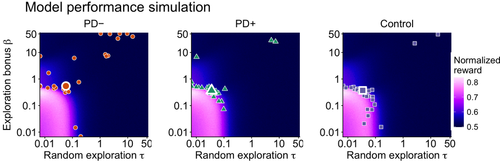

```r
# simulation results (pre-computed) using modelResults.R
# due to the file size limit on github we only store the mean values whcih are then plotted
# files with full simulation data:

# sim  <-  read.csv('modelResults/simulatedModels_local_lambda_0_5.csv') # large (>2TB) csv file
# saveRDS(sim, 'modelResults/simulatedModels_local_lambda_0_5.rds') # still too large
# sim <- readRDS('modelResults/simulatedModels_local_lambda_0_5.rds')


# normalize reward
# sim$meanReward = sim$mu / 50
#
# sim_means <-  sim %>%
#   group_by(tau,beta) %>%
#   summarise(meanReward = mean(mu)) %>%
#   mutate(meanReward = meanReward/50) %>%
#   mutate(beta_log10 = log10(beta),
#          tau_log10 = log10(tau)
#   )

# write.csv(sim_means, 'modelResults/simulatedModels_means_lambda_0_5.csv')

#get data, laready averaged across 1000 learners per paramater combination)
sim_means  <-  read.csv('modelResults/simulatedModels_means_lambda_0_5.csv')

# tick positions in the original scale

#lower_bound <- exp(-5)  # ~0.0067
#upper_bound <- exp(4)   # ~54.598

bx <- c(0.001, 0.01, 0.1, 1, 10, 50) # exploration bonus beta
by <- c(0.001, 0.01, 0.1, 1, 10, 50) # temperature tau

# Control group
p_model_simulation_params_control <-
  ggplot(sim_means, aes(y = beta_log10, x = tau_log10, fill = meanReward)) +
  geom_raster() +
  scale_x_continuous(expression(paste('Random exploration ', tau)), breaks = log10(bx), labels = bx, expand = c(0,0)) +
  scale_y_continuous( expression(paste('Exploration bonus ', beta)), breaks = log10(by), labels = by, expand = c(0,0)) +
  # labs(y = expression(paste('Exploration bonus ', beta)),
  #      x = expression(paste('Random exploration ', tau))) +
  scale_fill_gradientn(colours = cet_pal(5, name = "l7"), name = "Normalized\nreward") + #l3 l6 l16 i5 "rainbow"
  geom_jitter( # add individual points
    data = subset(marker2, group == "Control"),
    aes(y = beta_log10, x = tau_log10, shape = group, colour = group),
    inherit.aes = FALSE,
    size = 3,
    fill = "#7570b3",
    shape = 22,
    stroke = 0.5,
    color = "white",
    width = 0
  ) +
  geom_point( # add median
    data = subset(marker, group == "Control"),
    aes(y = beta_log10, x = tau_log10, colour = group),
    inherit.aes = FALSE,
    shape = 22,
    size = 5,
    stroke = 2,
    fill = "#7570b3",
    color = "white"
  ) +
  ggtitle("Control") +
  theme_classic() +
  theme(strip.background = element_blank(),
        strip.text = element_text(color = "black", size=18),
        legend.position = "none",
        axis.title = element_text(size = 18),
        axis.text = element_text(size = 18),
        plot.title = element_text(size = 18, hjust = 0.5),
        axis.title.y = element_blank()
  )

#p_model_simulation_params_control

# PD- group
p_model_simulation_params_pd_off <-
  ggplot(sim_means, aes(y = beta_log10, x = tau_log10, fill = meanReward)) +
  geom_raster() +
  scale_x_continuous(expression(paste('Random exploration ', tau)), breaks = log10(bx), labels = bx, expand = c(0,0)) +
  scale_y_continuous( expression(paste('Exploration bonus ', beta)), breaks = log10(by), labels = by, expand = c(0,0)) +
  scale_fill_gradientn(colours = cet_pal(5, name = "l7"), name = "Normalized\nreward") + #l3 l16 i5 "rainbow"
  geom_jitter( # add individual points
    data = subset(marker2, group == "PD-"),
    aes(y = beta_log10, x = tau_log10, shape = group, colour = group),
    inherit.aes = FALSE,
    size = 3,
    color = "white",
    fill = "#d95f02",
    shape = 21,
    stroke = 0.5,
    width = 0
  ) +
  geom_point( # add median
    data = subset(marker, group == "PD-"),
    aes(y = beta_log10, x = tau_log10, colour = group),
    inherit.aes = FALSE,
    shape = 21,
    size = 5,
    stroke = 2,
    fill = "#d95f02",
    color = "white"
  ) +
  ggtitle("PD\u2212") +
  theme_classic() +
  theme(strip.background = element_blank(),
        strip.text = element_text(color = "black", size=18),
        legend.position = "none",
        axis.title = element_text(size = 18),
        axis.text = element_text(size = 18),
        plot.title = element_text(size = 18, hjust = 0.5)
  )

# PD+ group
p_model_simulation_params_pd_on <-
  ggplot(sim_means, aes(y = beta_log10, x = tau_log10, fill = meanReward)) +
  geom_raster() +
  scale_x_continuous(expression(paste('Random exploration ', tau)), breaks = log10(bx), labels = bx, expand = c(0,0)) +
  scale_y_continuous( expression(paste('Exploration bonus ', beta)), breaks = log10(by), labels = by, expand = c(0,0)) +
  scale_fill_gradientn(colours = cet_pal(5, name = "l7"), name = "Normalized\nreward") + #l3 l16 i5 "rainbow"
  geom_jitter( # add individual points
    data = subset(marker2, group == "PD+"),
    aes(y = beta_log10, x = tau_log10, shape = group, colour = group),
    inherit.aes = FALSE,
    size = 3,
    color = "white",
    fill = "#1b9e77",
    shape = 24,
    stroke = 0.5,
    width = 0
  ) +
  geom_point( # add median
    data = subset(marker, group == "PD+"),
    aes(y = beta_log10, x = tau_log10, colour = group),
    inherit.aes = FALSE,
    shape = 24,
    size = 5,
    stroke = 2,
    fill = "#1b9e77",
    color = "white"
  ) +
  ggtitle("PD+") +
  theme_classic() +
  theme(strip.background = element_blank(),
        strip.text = element_text(color = "black", size=18),
        legend.position = "none",
        axis.title = element_text(size = 18),
        axis.text = element_text(size = 18),
        plot.title = element_text(size = 18, hjust = 0.5),
        axis.title.y = element_blank()
  )
# p_model_simulation_params_pd_on

# Extract legend
shared_legend <- cowplot::get_legend(
  p_model_simulation_params_control +
    theme(legend.position = "right",
          legend.title = element_text(size = 16),
          legend.text  = element_text(size = 14))
)

# combine plots
p_model_simulation_params_combined <- cowplot::plot_grid(
  p_model_simulation_params_pd_off,
  p_model_simulation_params_pd_on,
  p_model_simulation_params_control,
  nrow = 1, align = "hv", axis = "tblr", rel_widths = c(1,1,1),
  labels = NULL
)

# add  legend
p_model_simulation_params_combined <- cowplot::plot_grid(
  p_model_simulation_params_combined, shared_legend,
  ncol = 2, rel_widths = c(1, 0.10)
)

# add title
p_model_simulation_params <- ggdraw() +
  draw_label(
    "Model performance simulation",
    x = 0.05, y = 0.99,
    hjust = 0,
    vjust = 1,
    size = 24
  ) +
  draw_plot(p_model_simulation_params_combined, y = 0, height = 0.9)

p_model_simulation_params
ggsave("plots/S6_model_simulation_params_lambda_0_5.png", p_model_simulation_params, width = 14, height = 5, dpi = 300)
```

## References

Abbott, A. (2010). Levodopa: The story so far. *Nature*, *466*(7310), S6–S7.

Auer, P. (2002). Using confidence bounds for exploitation-exploration trade-offs. *Journal of Machine Learning Research*, *3*(Nov), 397–422.

Beck, A. T., Steer, R. A., & Brown, G. (1996). *Beck depression inventory–II (BDI-II) [database record]*. APA PsycTests. https://doi.org/10.1037/t00742-000

Chakroun, K., Mathar, D., Wiehler, A., Ganzer, F., & Peters, J. (2020). Dopaminergic modulation of the exploration/exploitation trade-off in human decision-making. *eLife*, *9*, e51260. https://doi.org/10.7554/eLife.51260

Dayan, P., Kakade, S., & Montague, P. R. (2000). Learning and selective attention. *Nature Neuroscience*, *3*(11), 1218–1223.

Djamshidian, A., O’Sullivan, S. S., Wittmann, B. C., Lees, A. J., & Averbeck, B. B. (2011). Novelty seeking behaviour in parkinson’s disease. *Neuropsychologia*, *49*(9), 2483–2488. https://doi.org/10.1016/j.neuropsychologia.2011.04.026

Doorn, J. van, Ly, A., Marsman, M., & Wagenmakers, E.-J. (2018). Bayesian inference for kendall’s rank correlation coefficient. *The American Statistician*, *72*, 303–308.

Doorn, J. van, Ly, A., Marsman, M., & Wagenmakers, E.-J. (2020). Bayesian rank-based hypothesis testing for the rank sum test, the signed rank test, and spearman’s $\rho$. *Journal of Applied Statistics*, *47*(16), 2984–3006.

Folstein, M. F., Folstein, S. E., & McHugh, P. R. (1975). “Mini-mental state”’: A practical method for grading the cognitive state of patients for the clinician. *Journal of Psychiatric Research*, *12*(3), 189–198.

Gershman, S. J. (2015). A unifying probabilistic view of associative learning. *PLoS Comput Biol*, *11*(11), e1004567.

Gilmour, W., Mackenzie, G., Feile, M., Tayler-Grint, L., Suveges, S., Macfarlane, J. A., Macleod, A. D., Marshall, V., Grunwald, I. Q., Steele, J. D., et al. (2024). Impaired value-based decision-making in parkinson’s disease apathy. *Brain*, *147*(4), 1362–1376.

Giron, A. P., Ciranka, S., Schulz, E., Bos, W. van den, Ruggeri, A., Meder, B., & Wu, C. M. (2023). Developmental changes in exploration resemble stochastic optimization. *Nature Human Behaviour*, *7*(11), 1955–1967. https://doi.org/ ( )

Goetz, C. G., Poewe, W., Rascol, O., Sampaio, C., Stebbins, G. T., Counsell, C., Giladi, N., Holloway, R. G., Moore, C. G., Wenning, G. K., et al. (2004). Movement disorder society task force report on the hoehn and yahr staging scale: Status and recommendations the movement disorder society task force on rating scales for parkinson’s disease. *Movement Disorders*, *19*(9), 1020–1028.

Hautzinger, M., Keller, F., & Kühner, C. (2006). *Beck depressions-inventar (BDI-II)*. Harcourt Test Services.

Hoehn, M. M., & Yahr, M. D. (1967). Parkinsonism: Onset, progression, and mortality. *Neurology*, *17*(5), 427–427.

Meder, B., Wu, C. M., Schulz, E., & Ruggeri, A. (2021). Development of directed and random exploration in children. *Developmental Science*, *24*(4), e13095. https://doi.org/https://doi.org/10.1111/desc.13095

Morey, R. D., & Rouder, J. N. (2024). *BayesFactor: Computation of bayes factors for common designs*. https://doi.org/10.32614/CRAN.package.BayesFactor

Mullen, K. M., Ardia, D., Gil, D. L., Windover, D., & Cline, J. (2011). DEoptim: An R package for global optimization by differential evolution. *Journal of Statistical Software*, *40*(6), 1–26. https://doi.org/10.18637/jss.v040.i06

Rescorla, R. A., & Wagner, A. R. (1972). A theory of Pavlovian conditioning: Variations in the effectiveness of reinforcement and nonreinforcement. *Classical Conditioning II: Current Research and Theory*, *2*, 64–99.

Rigoux, L., Stephan, K. E., Friston, K. J., & Daunizeau, J. (2014). Bayesian model selection for group studies—revisited. *Neuroimage*, *84*, 971–985.

Schulz, E., Speekenbrink, M., & Krause, A. (2018). A tutorial on gaussian process regression: Modelling, exploring, and exploiting functions. *Journal of Mathematical Psychology*, *85*, 1–16.

Schulz, E., Wu, C. M., Ruggeri, A., & Meder, B. (2019). Searching for rewards like a child means less generalization and more directed exploration. *Psychological Science*, *30*(11), 1561–1572. https://doi.org/10.1177/0956797619863663

Seymour, B., Barbe, M., Dayan, P., Shiner, T., Dolan, R., & Fink, G. R. (2016). Deep brain stimulation of the subthalamic nucleus modulates sensitivity to decision outcome value in parkinson’s disease. *Scientific Reports*, *6*(1), 32509.

Shohamy, D., Myers, C. E., Geghman, K. D., Sage, J., & Gluck, M. A. (2006). L-dopa impairs learning, but spares generalization, in parkinson’s disease. *Neuropsychologia*, *44*(5), 774–784.

Tambasco, N., Romoli, M., & Calabresi, P. (2018). Levodopa in parkinson’s disease: Current status and future developments. *Current Neuropharmacology*, *16*(8), 1239–1252.

Watkins, C. J., & Dayan, P. (1992). Q-learning. *Machine Learning*, *8*(3), 279–292.

Williams, C. K., & Rasmussen, C. E. (2006). *Gaussian processes for machine learning*. MIT Press Cambridge, MA.

Witt, A., Toyokawa, W., Lala, K. N., Gaissmaier, W., & Wu, C. M. (2024). Humans flexibly integrate social information despite interindividual differences in reward. *Proceedings of the National Academy of Sciences*, *121*(39), e2404928121. https://doi.org/10.1073/pnas.2404928121

Wu, C. M., Meder, B., & Schulz, E. (2025). Unifying principles of generalization: Past, present, and future. *Annual Review of Psychology*, *76*, 275–302. https://doi.org/https://doi.org/10.1146/annurev-psych-021524-110810

Wu, C. M., Schulz, E., Garvert, M. M., Meder, B., & Schuck, N. W. (2020). Similarities and differences in spatial and non-spatial cognitive maps. *PLOS Computational Biology*, *16*(9), e1008149. https://doi.org/10.1371/journal.pcbi.1008149

Wu, C. M., Schulz, E., Pleskac, T. J., & Speekenbrink, M. (2022). Time pressure changes how people explore and respond to uncertainty. *Scientific Reports*, *12*, 1–14. https://doi.org/https://doi.org/10.1038/s41598-022-07901-1

Wu, C. M., Schulz, E., Speekenbrink, M., Nelson, J. D., & Meder, B. (2018). Generalization guides human exploration in vast decision spaces. *Nature Human Behaviour*, *2*, 915–924. https://doi.org/10.1038/s41562-018-0467-4